# Quantified Palaeoecology - Rates of Change and Ordination

Author

Ian Matthews

## Introduction

Exploration of data is often required in datasets with lots of variables, observations, or both. The principal way I undertake this is multivariate exploratory data analysis. I use this approach to understand the major changes within a dataset but also for dimension reduction to help build better models of change. The rescaling of data along the line of maximum variation captures the most variance while reducing the total number of variables to examine. This approach can often also help us to better understand the links between observations and variables by plotting ordination scatter plots.In this session, I will first cover data plotting and determining rates of change (RoC) in samples, then I will cover four approaches to multivariate analysis. The first three are classical ordination approach using Principal components analysis (PCA), Correspondence analysis (CA), and its detrended version (DCA). Last, I will highlight the potential of direct ordination to explain how much variability can be attributed to specific climatic forcing of our species data. The first parts will use pollen data while the last will utilise the Norwegian modern chironomid dataset.

## Tidy data

The first concern when undertaking any multivariate analysis it that you require Tidy data. In these cases each observation is a row and each variable is a column. This ensures a rectangular data frame with no extraneous information.

The data sets we will use today are from two sources. The first is a palaeoecological dataset from pollen grain counts collected from a sediment core taken out of a lake in Scotland (figure 1). We will plot the data and then use RoC and multivariate analysis to explore the relationships between taxa and observations (observations in this case are derived from sample depths going down into the sediment core and also going further back in time). This type of research is carried out to understand temporal changes in vegetative history on the landscape and ultimately help with long term landscape development and management. The second approach relates to direct ordination where environmental variables are used understand changes within assemblages. For this I will use a modern environmental data and midge (chironomidae) data set.

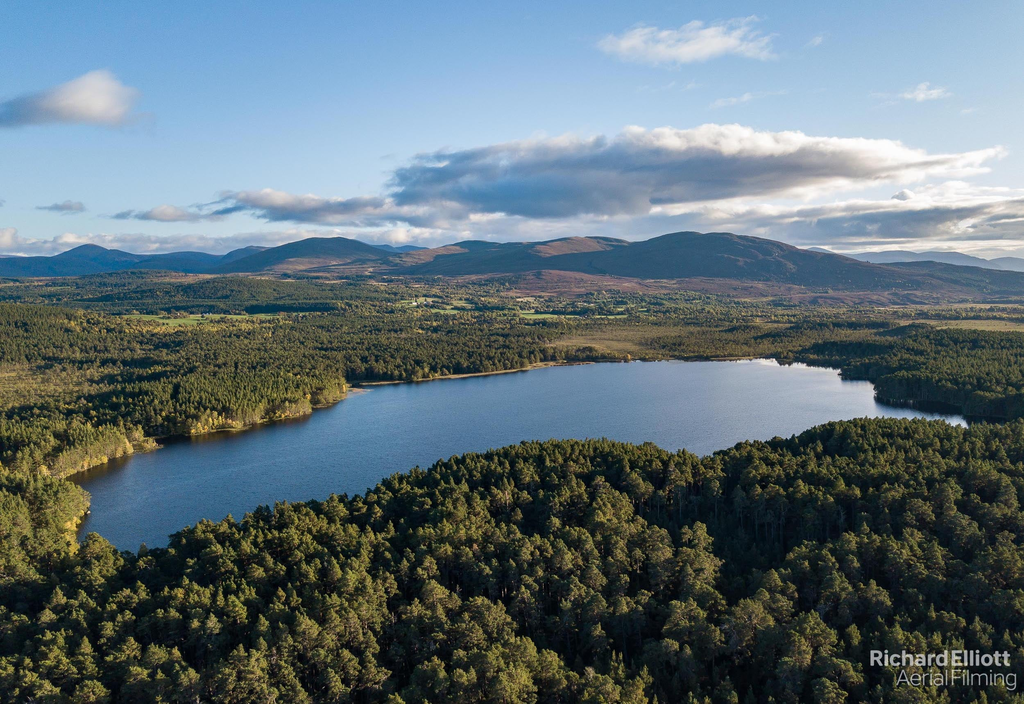

Loch Garten and Abernethy Forest, Scotland, first worked on by (Birks 1970; BIRKS and MATHEWES 1978; Matthews et al. 2011).

To do this we require a series of packages to be loaded. I tend to do these first in order to be consistent with my work.

```r
library(rioja) # plotting pollen data
library(analogue) # Used for modern analogue testing
library(readr) # loading .csv files
library(vegan) # Community Ecology Package Ordination methods, diversity analysis and other functions for community and vegetation ecologists
library(factoextra)  # A nice implementation of PCA in ggplot2 style
library(gridExtra) # base graphics package
library(readxl) # read excel files
library(gt) # Produce better tables in R
library(ggrepel) # better labels on ggplots
library(ggdensity) # highest denisty regions geom.
library(patchwork)# stacking plots together
library(ggpubr) # Publication ready plots in ggplot
```

First we load in the Abernethy Forest pollen data. We then view it to check that it has loaded correctly.

The pollen data are compositional in form and are produced as a percentage. This means that the data are not independent of each other but must co-vary. This can create some challenges when undertaking ordination, but we will explore these below.

```r
# This reads the csv sheet percentages and enables R to view the sheet.
poll <- read_csv("Abernethy.csv")
# Enables the viewing in R of the data to be used in the project.
head(poll)
```

```
# A tibble: 6 × 59
  Depth `Betula undiff.` `Alnus glutinosa` Quercus `Pinus sylvestris`  Acer
  <dbl>            <dbl>             <dbl>   <dbl>              <dbl> <dbl>
1   410             62.3             0       0.512               1.54     0
2   415             70.7             0       0.556               1.85     0
3   420             68.9             0.177   0                   2.12     0
4   425             62.3             0       0.345               1.38     0
5   430             73.9             0       0                   2.19     0
6   435             68.6             0       0                   2.84     0
# ℹ 53 more variables: `Fraxinus excelsior` <dbl>, Populus <dbl>,
#   `Tilia cordata` <dbl>, Ulmus <dbl>, `Juniperus communis` <dbl>,
#   `Corylus/Myrica` <dbl>, `Calluna vulgaris` <dbl>, Empetrum <dbl>,
#   Ericaceae <dbl>, `Hedera helix` <dbl>, Rubiaceae <dbl>,
#   `Salix undiff.` <dbl>, Viburnum <dbl>, Poaceae <dbl>, Cyperaceae <dbl>,
#   Amaranthaceae <dbl>, Apiaceae <dbl>, `Armeria-type` <dbl>, Artemisia <dbl>,
#   Asteraceae <dbl>, Campanulaceae <dbl>, `Caryophyllaceae undiff.` <dbl>, …
```

If you are using Quarto or Rmarkdown you may wish to produce a better looking table of your data. This is particularly true if you wish to present material on slides. I use the gt package for this.

```r
poll %>%
  round(digits = 2) %>%
  gt()
```

| Depth | Betula undiff. | Alnus glutinosa | Quercus | Pinus sylvestris | Acer | Fraxinus excelsior | Populus | Tilia cordata | Ulmus | Juniperus communis | Corylus/Myrica | Calluna vulgaris | Empetrum | Ericaceae | Hedera helix | Rubiaceae | Salix undiff. | Viburnum | Poaceae | Cyperaceae | Amaranthaceae | Apiaceae | Armeria-type | Artemisia | Asteraceae | Campanulaceae | Caryophyllaceae undiff. | Epilobium | Fabaceae undiff. | … |
| --- | --- | --- | --- | --- | --- | --- | --- | --- | --- | --- | --- | --- | --- | --- | --- | --- | --- | --- | --- | --- | --- | --- | --- | --- | --- | --- | --- | --- | --- | --- |
| 410 | 62.29 | 0.00 | 0.51 | 1.54 | 0.00 | 0 | 0.34 | 0 | 0.51 | 0.85 | 23.55 | 3.41 | 0.34 | 0.00 | 0 | 0.00 | 1.88 | 0.00 | 3.24 | 1.02 | 0.00 | 0.00 | 0.00 | 0.00 | 0.00 | 0.0 | 0.00 | 0.00 | 0.00 | … |
| 415 | 70.74 | 0.00 | 0.56 | 1.85 | 0.00 | 0 | 0.19 | 0 | 0.74 | 0.74 | 17.04 | 2.22 | 0.56 | 0.00 | 0 | 0.19 | 1.85 | 0.00 | 2.41 | 0.19 | 0.00 | 0.00 | 0.00 | 0.00 | 0.00 | 0.0 | 0.00 | 0.00 | 0.00 | … |
| 420 | 68.90 | 0.18 | 0.00 | 2.12 | 0.00 | 0 | 0.88 | 0 | 0.35 | 1.41 | 17.31 | 1.41 | 0.53 | 0.00 | 0 | 0.18 | 3.18 | 0.00 | 2.47 | 0.88 | 0.00 | 0.00 | 0.00 | 0.00 | 0.00 | 0.0 | 0.00 | 0.00 | 0.00 | … |
| 425 | 62.35 | 0.00 | 0.35 | 1.38 | 0.00 | 0 | 0.69 | 0 | 0.35 | 5.53 | 12.44 | 3.80 | 1.38 | 0.00 | 0 | 0.00 | 6.22 | 0.00 | 3.45 | 0.86 | 0.00 | 0.00 | 0.00 | 0.00 | 0.00 | 0.0 | 0.00 | 0.00 | 0.00 | … |
| 430 | 73.91 | 0.00 | 0.00 | 2.19 | 0.00 | 0 | 0.36 | 0 | 0.00 | 5.66 | 6.75 | 3.47 | 1.46 | 0.00 | 0 | 0.00 | 0.00 | 0.00 | 4.20 | 0.73 | 0.18 | 0.00 | 0.00 | 0.00 | 0.00 | 0.0 | 0.00 | 0.00 | 0.00 | … |
| 435 | 68.56 | 0.00 | 0.00 | 2.84 | 0.00 | 0 | 0.36 | 0 | 0.00 | 11.01 | 1.78 | 1.95 | 3.20 | 0.00 | 0 | 0.18 | 4.44 | 0.00 | 3.20 | 1.24 | 0.00 | 0.00 | 0.00 | 0.00 | 0.00 | 0.0 | 0.00 | 0.00 | 0.00 | … |
| 440 | 63.82 | 0.00 | 0.00 | 3.26 | 0.00 | 0 | 0.62 | 0 | 0.00 | 8.54 | 1.24 | 3.73 | 1.55 | 0.00 | 0 | 0.31 | 4.19 | 0.00 | 8.54 | 2.17 | 0.00 | 0.00 | 0.00 | 0.00 | 0.00 | 0.0 | 0.00 | 0.00 | 0.00 | … |
| 445 | 66.44 | 0.00 | 0.00 | 2.19 | 0.00 | 0 | 0.84 | 0 | 0.00 | 10.79 | 2.02 | 1.85 | 1.85 | 0.00 | 0 | 0.00 | 4.72 | 0.00 | 5.73 | 2.19 | 0.00 | 0.17 | 0.00 | 0.00 | 0.00 | 0.0 | 0.00 | 0.00 | 0.00 | … |
| 450 | 53.99 | 0.00 | 0.00 | 3.83 | 0.00 | 0 | 0.16 | 0 | 0.00 | 20.45 | 0.96 | 2.72 | 1.44 | 0.00 | 0 | 0.16 | 5.11 | 0.00 | 7.19 | 2.56 | 0.00 | 0.00 | 0.00 | 0.00 | 0.00 | 0.0 | 0.00 | 0.00 | 0.00 | … |
| 455 | 51.92 | 0.00 | 0.00 | 0.67 | 0.00 | 0 | 0.00 | 0 | 0.00 | 22.04 | 0.17 | 0.33 | 5.18 | 0.00 | 0 | 0.17 | 3.01 | 0.00 | 13.02 | 2.00 | 0.00 | 0.00 | 0.00 | 0.17 | 0.33 | 0.0 | 0.00 | 0.00 | 0.00 | … |
| 460 | 39.73 | 0.00 | 0.00 | 1.52 | 0.00 | 0 | 0.84 | 0 | 0.00 | 34.68 | 0.84 | 2.36 | 3.20 | 0.00 | 0 | 0.51 | 4.55 | 0.17 | 7.58 | 2.19 | 0.00 | 0.00 | 0.00 | 0.00 | 0.00 | 0.0 | 0.00 | 0.00 | 0.00 | … |
| 465 | 17.50 | 0.00 | 0.00 | 2.14 | 0.00 | 0 | 0.00 | 0 | 0.00 | 19.29 | 0.89 | 4.46 | 21.79 | 0.36 | 0 | 0.54 | 2.68 | 0.00 | 19.64 | 8.75 | 0.00 | 0.00 | 0.00 | 0.00 | 0.18 | 0.0 | 0.00 | 0.00 | 0.00 | … |
| 470 | 3.76 | 0.00 | 0.47 | 1.41 | 0.00 | 0 | 0.00 | 0 | 0.00 | 0.47 | 0.00 | 0.47 | 1.88 | 0.47 | 0 | 0.00 | 2.82 | 0.00 | 34.74 | 20.19 | 0.47 | 0.47 | 0.47 | 13.15 | 1.41 | 0.0 | 0.47 | 0.00 | 0.94 | … |
| 475 | 4.69 | 0.29 | 0.00 | 6.16 | 0.29 | 0 | 0.00 | 0 | 0.00 | 0.00 | 0.29 | 0.29 | 1.17 | 0.29 | 0 | 0.00 | 3.81 | 0.00 | 9.09 | 13.49 | 0.00 | 0.00 | 0.29 | 41.94 | 0.29 | 0.0 | 1.47 | 0.00 | 3.23 | … |
| 480 | 6.85 | 0.00 | 0.00 | 4.79 | 0.00 | 0 | 0.00 | 0 | 0.00 | 0.00 | 0.00 | 0.34 | 2.74 | 0.34 | 0 | 0.00 | 4.79 | 0.00 | 6.51 | 6.16 | 0.34 | 0.34 | 0.34 | 45.21 | 0.68 | 0.0 | 2.40 | 0.00 | 3.08 | … |
| 485 | 5.58 | 0.00 | 0.00 | 5.58 | 0.00 | 0 | 0.00 | 0 | 0.00 | 0.40 | 0.80 | 1.59 | 1.59 | 0.40 | 0 | 0.00 | 6.77 | 0.00 | 7.57 | 3.98 | 0.00 | 0.40 | 0.00 | 38.65 | 0.00 | 0.0 | 1.99 | 0.00 | 3.19 | … |
| 490 | 5.47 | 0.30 | 0.00 | 2.13 | 0.00 | 0 | 0.00 | 0 | 0.00 | 0.30 | 0.30 | 0.00 | 3.04 | 0.30 | 0 | 0.00 | 4.56 | 0.00 | 3.95 | 5.47 | 0.00 | 0.00 | 0.00 | 65.05 | 0.00 | 0.0 | 0.91 | 0.00 | 0.30 | … |
| 500 | 8.10 | 0.35 | 0.00 | 3.87 | 0.00 | 0 | 0.00 | 0 | 0.35 | 0.00 | 0.35 | 0.35 | 2.82 | 0.35 | 0 | 0.00 | 9.15 | 0.00 | 6.69 | 4.93 | 0.00 | 0.35 | 0.00 | 45.77 | 0.70 | 0.0 | 3.52 | 0.00 | 2.46 | … |
| 505 | 6.92 | 0.58 | 0.00 | 0.58 | 0.00 | 0 | 0.00 | 0 | 0.00 | 1.15 | 0.29 | 0.86 | 2.88 | 0.29 | 0 | 0.00 | 5.48 | 0.00 | 6.63 | 6.34 | 0.29 | 0.29 | 0.29 | 55.62 | 0.29 | 0.0 | 1.15 | 0.29 | 0.29 | … |
| 510 | 10.32 | 0.00 | 0.00 | 3.57 | 0.00 | 0 | 0.00 | 0 | 0.00 | 1.19 | 0.40 | 0.00 | 3.97 | 0.00 | 0 | 0.00 | 5.16 | 0.00 | 7.14 | 6.35 | 0.00 | 0.00 | 0.00 | 53.17 | 0.00 | 0.4 | 1.19 | 0.00 | 0.00 | … |
| 515 | 27.33 | 0.00 | 0.00 | 4.26 | 0.00 | 0 | 0.00 | 0 | 0.00 | 11.13 | 1.15 | 0.33 | 19.48 | 0.00 | 0 | 0.00 | 1.64 | 0.00 | 16.69 | 10.47 | 0.00 | 0.16 | 0.00 | 0.33 | 0.49 | 0.0 | 0.82 | 0.00 | 0.00 | … |
| 520 | 31.88 | 0.00 | 0.00 | 1.05 | 0.00 | 0 | 0.00 | 0 | 0.00 | 2.26 | 0.70 | 0.00 | 34.84 | 0.00 | 0 | 0.52 | 1.39 | 0.00 | 12.02 | 8.19 | 0.00 | 0.00 | 0.00 | 1.39 | 0.35 | 0.0 | 0.00 | 0.00 | 0.00 | … |
| 525 | 20.77 | 0.00 | 0.00 | 0.88 | 0.00 | 0 | 0.00 | 0 | 0.00 | 0.00 | 0.53 | 0.35 | 35.56 | 0.35 | 0 | 0.18 | 1.41 | 0.00 | 20.95 | 12.32 | 0.00 | 0.00 | 0.00 | 1.23 | 0.18 | 0.0 | 0.00 | 0.00 | 0.00 | … |
| 530 | 18.28 | 0.00 | 0.18 | 0.18 | 0.00 | 0 | 0.00 | 0 | 0.00 | 0.00 | 0.18 | 0.00 | 34.73 | 0.00 | 0 | 0.18 | 2.56 | 0.00 | 14.81 | 6.58 | 0.00 | 0.00 | 0.00 | 1.10 | 0.91 | 0.0 | 0.00 | 0.00 | 0.18 | … |
| 535 | 4.40 | 0.00 | 1.26 | 1.89 | 0.00 | 0 | 0.00 | 0 | 0.00 | 1.26 | 0.00 | 0.00 | 1.89 | 0.00 | 0 | 0.00 | 33.33 | 0.00 | 23.90 | 6.29 | 0.00 | 0.00 | 0.63 | 1.26 | 1.26 | 0.0 | 0.00 | 0.63 | 0.63 | … |
| 540 | 2.97 | 0.00 | 0.99 | 1.98 | 0.00 | 0 | 0.00 | 0 | 0.00 | 0.00 | 0.00 | 0.00 | 0.99 | 0.00 | 0 | 0.99 | 15.84 | 0.00 | 20.79 | 6.93 | 0.00 | 0.00 | 0.00 | 1.98 | 1.98 | 0.0 | 0.00 | 0.99 | 0.99 | … |
| 545 | 7.62 | 0.95 | 0.00 | 8.57 | 0.00 | 0 | 0.00 | 0 | 0.95 | 0.00 | 0.95 | 0.00 | 3.81 | 0.00 | 0 | 0.00 | 5.71 | 0.00 | 14.29 | 11.43 | 0.00 | 0.00 | 0.00 | 0.95 | 2.86 | 0.0 | 0.00 | 0.00 | 0.00 | … |
| 550 | 1.04 | 0.00 | 1.04 | 2.08 | 0.00 | 0 | 0.00 | 0 | 0.00 | 0.00 | 1.04 | 0.00 | 1.04 | 0.00 | 0 | 1.04 | 5.21 | 0.00 | 9.38 | 20.83 | 1.04 | 0.00 | 0.00 | 4.17 | 8.33 | 0.0 | 3.12 | 0.00 | 0.00 | … |

```r
 # this rounds our data.frame to two decimal places and then produces a table of the data.
```

Tables aren’t great for data visualisation so we will plot the information in a stratigraphic chart. However, before we can do this we need to reduce our data so that only the most important taxa are displayed in a summary figure.

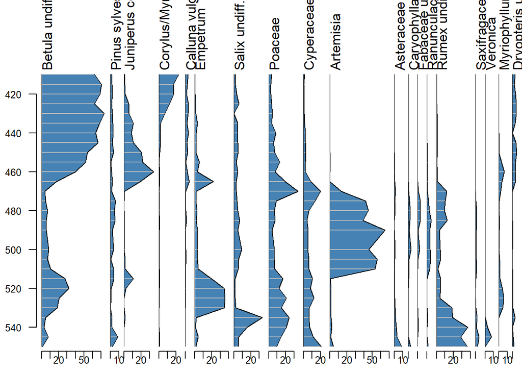

```r
poll2 <- round(poll, 2) #  We will round all our data to 2 decimal places.
Depth <- poll$Depth # we extract the depth information and then remove this column
poll2 <- poll2[ -c(1)]

# Use apply function to select poll the columns (taxa) by selecting 2 and maximum values
mx <- apply(poll2, 2, max)

# Make new spec file using poll where mx is greater than 3 %  to remove rare taxa.
spec <- poll2[, mx >3]

strat.plot(spec, scale.percent=TRUE,
           plot.bar = TRUE,
           plot.poly = TRUE,
           plot.line = TRUE,
           y.rev = TRUE,
           col.poly = "steelblue",
           yvar = Depth)
```

This is fine as a basic plot but we will format it so that it can be more easily understood.

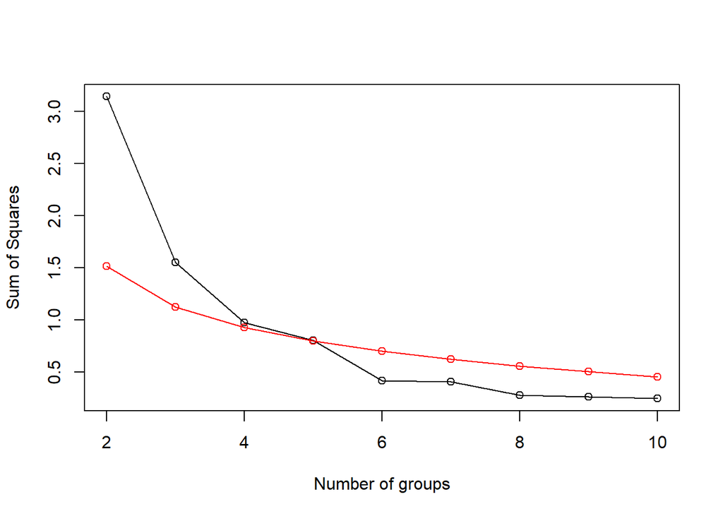

```r
# Calculate the Sq Chord Distance within the data
diss <- dist(sqrt(spec/100))

#Apply a clustering algorithm to the sequence is this instance hierarchical clustering
clust <- chclust(diss, method="coniss")

# broken stick model suggest n significant zones
bstick(clust)
```

This suggests that four or five different groups are viable in our data. We can add this information to our diagram and also tidy it up a little.

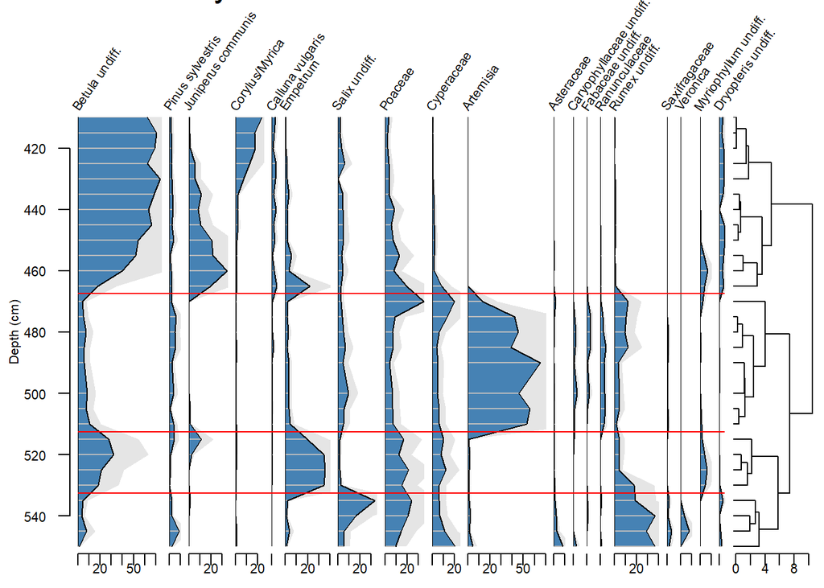

```r
x <- strat.plot(spec, yvar = Depth,
           y.rev=TRUE,
           xRight = 0.99,
           scale.percent=TRUE,
           plot.bar = TRUE,
           plot.poly = TRUE,
           plot.line = TRUE,
           col.poly = "steelblue",
           xLeft = 0.085,
           title="Abernethy Forest",
           ylabel="Depth (cm)",
           clust = clust,
           exag = TRUE,
           exag.mult = 2,
           srt.xlabel = 55,
           cex.xlabel = 0.65,
           cex.ylabel = 0.65,
           cex.yaxis = 0.7,
           cex.axis = 0.7
           ) # labels will change between sites

# add zones from CONISS
addClustZone(x, clust, 4, col="red") # zone number will change between sites
```

While we have reduced and simplified our plots, we haven’t really explored our data. The zonation picks out periods of change in the data but doesn’t allow us to understand this in a clear dataset. We need to report rates of change, and then we need to go beyond this and try to understand both the relationships between taxa (variables) and depths (observations). We can undertake ordination to achieve this. We have three main options for this, Correspondence analysis (CA), Detrended correspondence analysis (DCA - decorana), and Principal Components Analysis (PCA). There are a whole other suite of techniques we could explore, but these go beyond our needs in these data.

## Rate of Change (RoC)

We will constrain the rate of change in the Abernethy data using a dissimilarity measure. This looks to see how far samples vary from each other. Ideally this is calculated against age so that change over time can be identified, as we do not have a sufficient chronology for this we can plot against depth as a proxy for time.

First we will calculate dissimilarity using a Squared Chord Distance using the Hellinger method.

```r
distance_matrix <- as.matrix(vegdist(poll2, method = "hellinger", upper = TRUE, diag = FALSE))
distances <- diag(distance_matrix[-1, -ncol(distance_matrix)]) ## this extracts the most important information between sample differences.
```

Now we will need to determine the dissimilarity against depth.

```r
# Compute depth intervals (differences in depth)
depth_intervals <- diff(poll$Depth)

# Compute rate of change
rate_of_change <- distances / depth_intervals

# Combine into a dataframe
roc_df <- data.frame(
  depth = Depth[-1],  # Associate rate of change with the second sample in each pair
  RoC = rate_of_change
)

print(roc_df)
```

```
   depth        RoC
1    415 0.03280860
2    420 0.03262656
3    425 0.04670998
4    430 0.06043097
5    435 0.06024715
6    440 0.05241651
7    445 0.05380398
8    450 0.04455719
9    455 0.06406059
10   460 0.05606297
11   465 0.09414604
12   470 0.16198566
13   475 0.10455384
14   480 0.05247917
15   485 0.05894676
16   490 0.08082082
17   500 0.03371345
18   505 0.06648253
19   510 0.05601543
20   515 0.16632981
21   520 0.07073853
22   525 0.05441729
23   530 0.06169222
24   535 0.14902620
25   540 0.08727523
26   545 0.09554110
27   550 0.11855153
```

Last we will print this against depth to see where the biggest changes occur.

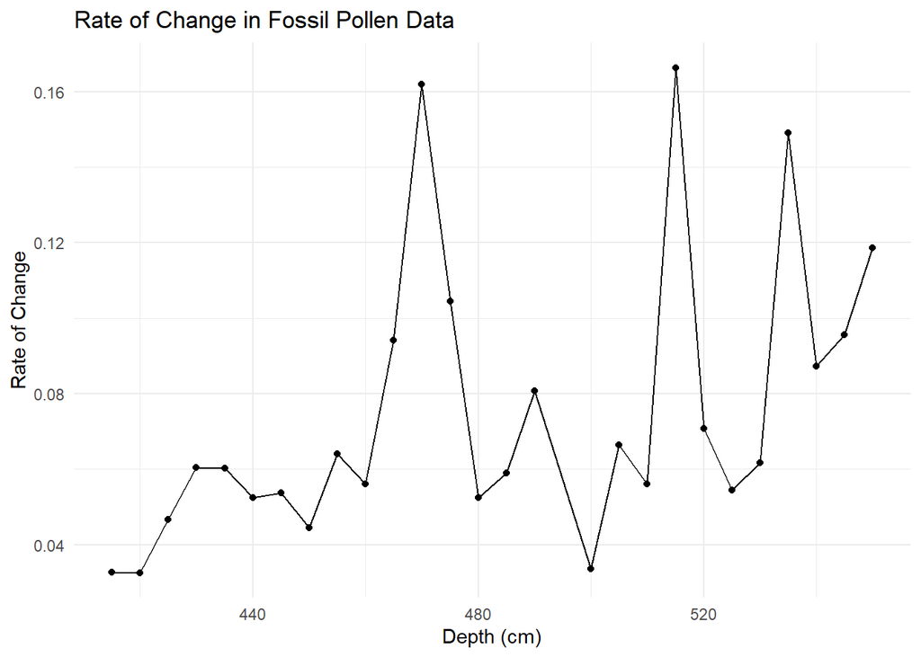

```r
ggplot(roc_df, aes(x = depth, y = RoC)) +
  geom_line() +
  geom_point() +
  theme_minimal() +
  labs(title = "Rate of Change in Fossil Pollen Data",
       x = "Depth (cm)",
       y = "Rate of Change")
```

This suggests three locations with the greatest RoC, these closely agree with the zone boundaries. The greatest zones of change occurs at the base of the record and we might find that adding a smooth line through the data will show longer term trends.

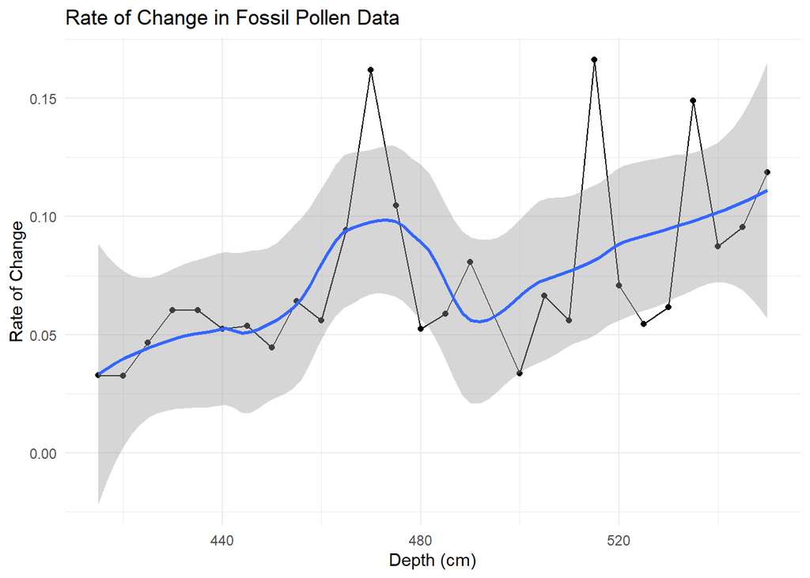

```r
ggplot(roc_df, aes(x = depth, y = RoC)) +
  geom_line() +
  geom_point() +
  geom_smooth(span = 0.5) +
  theme_minimal() +
  labs(title = "Rate of Change in Fossil Pollen Data",
       x = "Depth (cm)",
       y = "Rate of Change")
```

This generates interesting results. The smooth shows highest RoC at the start of the record which declinestoward 480 cm. This trend is interrupted by higher values between 480 - 460 cm. This suggests that the onset of Windermere interstadial conditions and the onset of the Holocene lead to the greatest changes in vegetation assemblages.

## Linear techniques -

### PCA

Ordination via PCA rescales our data utilising the line of maximum variation. It attempts to capture as much of the total variability found within a sample as possible. We will undertake this for the Abernethy data. To ensure the data are comparable we will first transform them through scaling and centering the data first. We will first look at the output and produce a scree plot to see how much variation can be captured by each axis.

```r
#produce a PCA
pcascores <- prcomp(spec, scale. = TRUE, center = TRUE)
summary(pcascores)
```

```
Importance of components:
                          PC1    PC2    PC3    PC4    PC5     PC6     PC7
Standard deviation     2.5293 1.8446 1.6539 1.1525 1.1257 1.05110 0.87484
Proportion of Variance 0.3367 0.1791 0.1440 0.0699 0.0667 0.05815 0.04028
Cumulative Proportion  0.3367 0.5158 0.6597 0.7297 0.7964 0.85450 0.89478
                           PC8     PC9    PC10    PC11    PC12    PC13    PC14
Standard deviation     0.69633 0.63288 0.57208 0.54010 0.41999 0.33105 0.29963
Proportion of Variance 0.02552 0.02108 0.01722 0.01535 0.00928 0.00577 0.00473
Cumulative Proportion  0.92030 0.94139 0.95861 0.97396 0.98325 0.98902 0.99374
                          PC15    PC16    PC17    PC18     PC19
Standard deviation     0.24772 0.19522 0.12703 0.05710 0.008004
Proportion of Variance 0.00323 0.00201 0.00085 0.00017 0.000000
Cumulative Proportion  0.99697 0.99898 0.99983 1.00000 1.000000
```

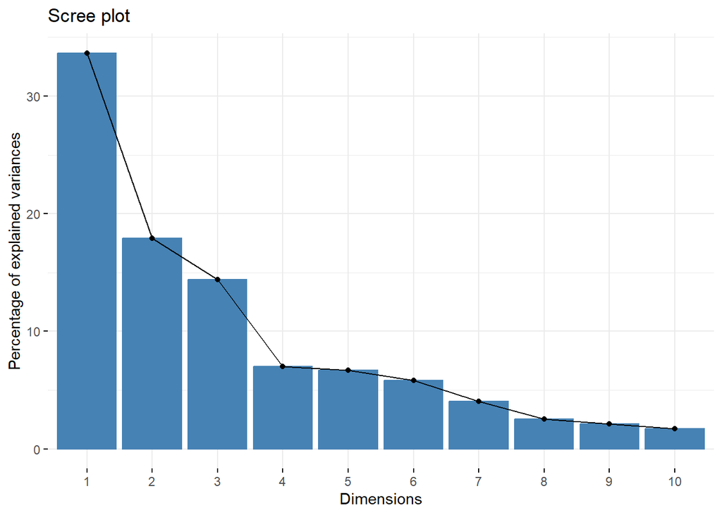

```r
fviz_eig(pcascores)
```

Axis 1 captures 33.7% of the total variation, while axis 2 captures 17.9%. Both of these capture c. 51.58% of the toal variation in the data. This is good to know but it doesn’t tell us which variables are most important. This requires a second plot including this information.

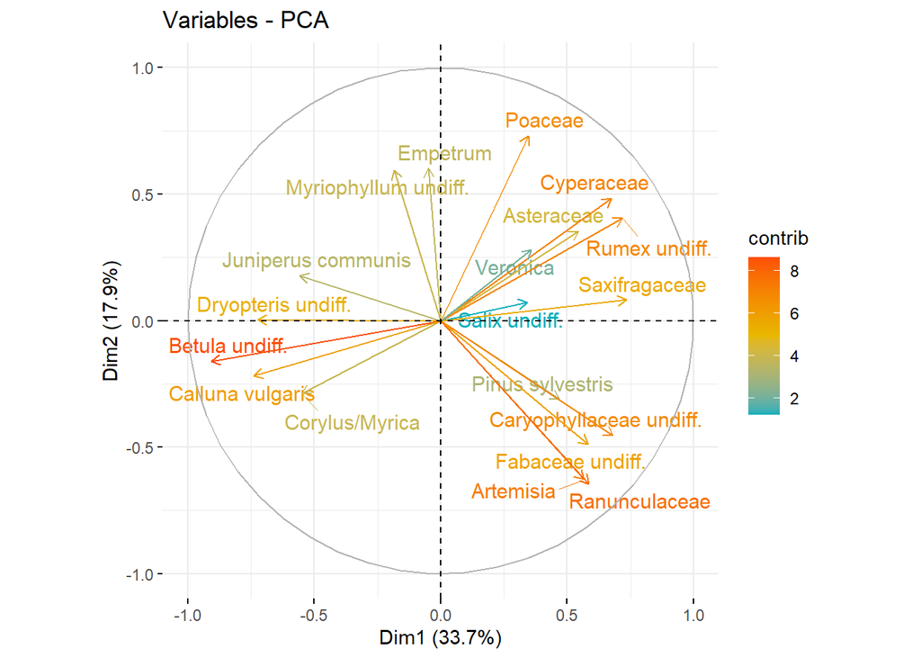

```r
fviz_pca_var(pcascores, col.var = "contrib", # Color by contributions to the PC
             gradient.cols = c("#00AFBB", "#E7B800", "#FC4E07"),
             repel = TRUE     # Avoid text overlapping
)
```

This biplot shows the position of our variables. Those most closely aligned to axis 1 influence it most. The colours in this plot also show the total contribution (importance). In this case *Betula*, *Rumex* and *Artemisia* are important for axis one. as the arrows point in different directions it means that while *Betula* levels are high, *Artemisia* and *Rumex* are low and vice versa. Poaceae is important for axis 2.

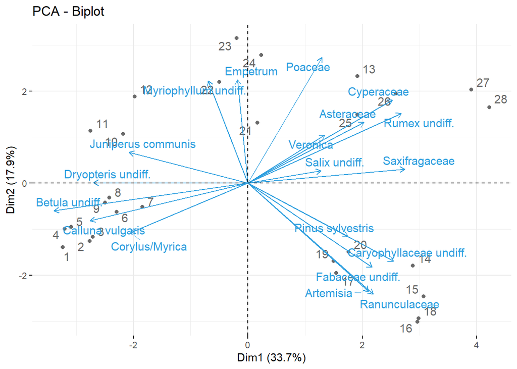

```r
fviz_pca_biplot(pcascores, repel = TRUE,
                col.var = "#2E9FDF", # Variables color
                col.ind = "#696969"  # Individuals color
)
```

This plot shows the samples (observations) against the variables and show which taxa are present in those samples e.g. samples 1-11 have *Betula*, *Calluna*, *Corylus*, *Juniperus* in them. When all these plots are combined we can see axis one is driven by stable woody vegetation at low values <0 and unstable herbaceous vegetation as higher values >0

However, the PCA has the issue surrounding monotone responses and doesn’t relfect unimodal change.

## Unimodal techniques

Technically these should be better for ecological data we will check this for our data and see whether it provides a better assessment of change.

### Correspondence analysis (CA)

This technique might better reflect the changes but can be strongly influenced by the arch effect. Can can see this in the plot below.

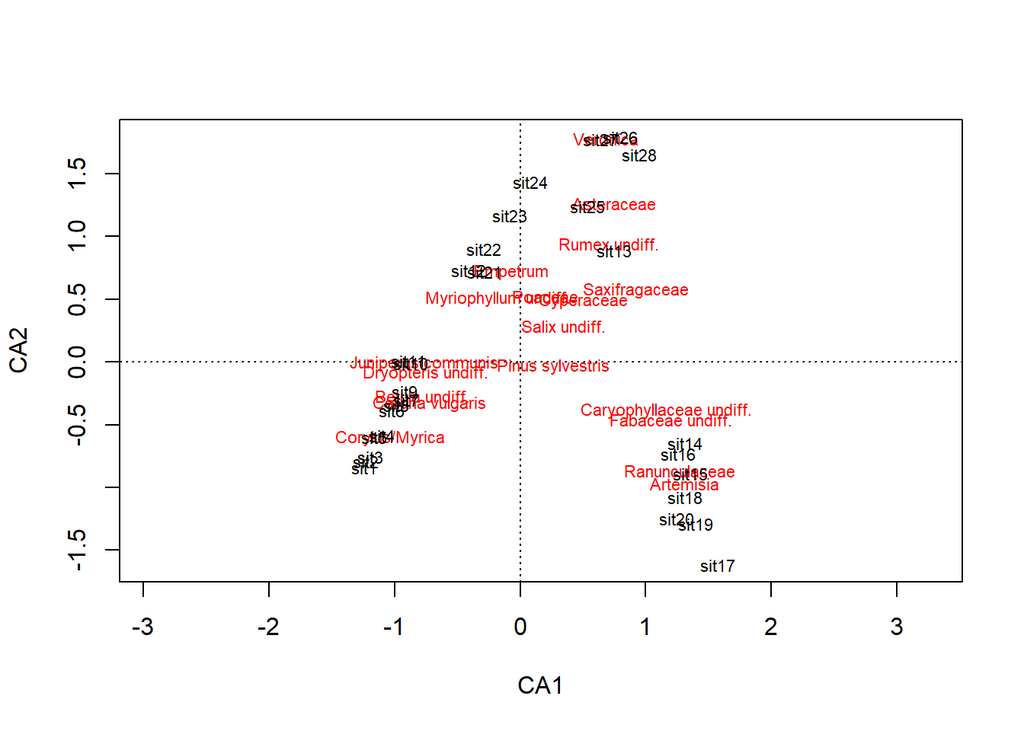

These types of plot are not very friendly to view. Additionally CA can introduce artefacts into the data in the same way as seen in PCA. Strong arch effects are common and need to be dealt with. Two options are open for data analysis:

1. Detrended Correspondence Analysis (DCA)
2. A data transformation to make data better applicable to linear methods found in PCA or RDA.

### Detrended Correspondence Analysis (DCA)

This breaks our data into segments using linear regression and then ‘flattens out’ the data. It has some advantages in that the axis lengths become measures of standard deviation in the data. The code below gives different information to a PCA and requires a bit more transformation to make sense of it.

```r
ord <- decorana(spec, iweigh=0)
ord # print results to console
```

```
Call:
decorana(veg = spec, iweigh = 0)

Detrended correspondence analysis with 26 segments.
Rescaling of axes with 4 iterations.
Total inertia (scaled Chi-square): 1.5433

                       DCA1   DCA2    DCA3    DCA4
Eigenvalues          0.5968 0.2585 0.11704 0.10957
Additive Eigenvalues 0.5968 0.2607 0.08745 0.06385
Decorana values      0.6029 0.1464 0.03023 0.01641
Axis lengths         2.7773 1.9883 1.01492 1.18480
```

We see axis lengths > 1.5-2 which means significnat change in our assemblage, remember that axis length units are now standard deviations. The length means this is likely to be the appropriate technique to use. We can convert this data to show how much variation is being captured.

```r
ord$evals # gives just the eigenvalue scores.
```

```
     DCA1      DCA2      DCA3      DCA4
0.5968280 0.2585449 0.1170379 0.1095696
```

```r
tot.in<-chisq.test(spec/sum(spec))$statistic
tot.in
```

```
X-squared
 1.543286
```

This give each axis against the total inertia (the sum of all the Eigenvalues). From this we can calculate a percentage figure.

```r
percent.explained<-round((ord$evals/tot.in)*100,2)
percent.explained
```

```
 DCA1  DCA2  DCA3  DCA4
38.67 16.75  7.58  7.10
```

So in this case 38.67% of the variation is captured by axis 1 and a further 16.75% of the variation is captured by axis 2. This means we can capture 55.42% of all variation in the dataset with a single plot. This is comparable to the PCA. We can plot this using the basic plotting commands of R to see how exactly the data is spread. In the following plot the taxa = names and the samples = circles. However, these types of plot are not particularly friendly to view with lots of overplotting..

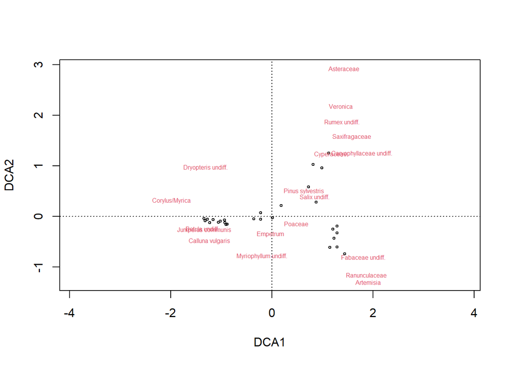

```r
plot(ord, choices=c(1,2), origin=TRUE,
     display=c("both"),
     cex = 0.5)
```

An alternative is to use ggplot2, but this requires some data manipulation. Note also the above plot is scaled to maximise the spacing between both samples and species, the output of the DCA does not automatically undertake that scaling.

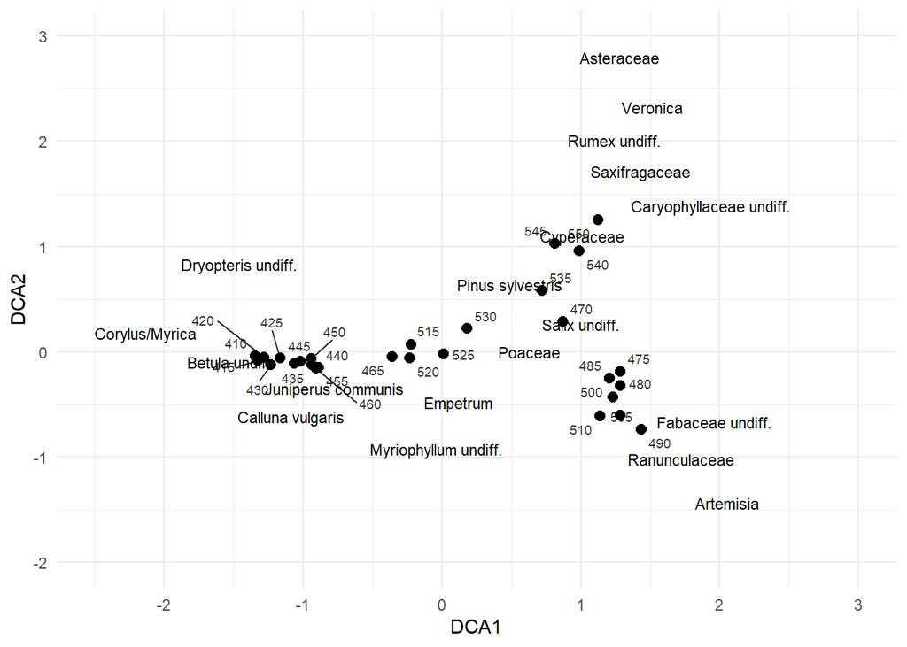

```r
dca.samples <- as.data.frame(scores(ord,  display = "sites", choices = 1:3))
dca.species<-as.data.frame(scores(ord,display="species",choice=1:3))
dca.samples<-cbind(Depth,dca.samples)
write.csv(dca.samples, "DCA_sample_scores.csv")
write.csv(dca.species, "DCA_species_scores.csv")

ggplot(data = dca.species, aes(x=DCA1, y=DCA2, label = rownames(dca.species))) +
  geom_text_repel(size = 3, direction = "both") +
  geom_point(data = dca.samples, inherit.aes = FALSE, aes(x = DCA1, y = DCA2), size = 2.5) +
  geom_text_repel(data = dca.samples, inherit.aes = FALSE, aes(x = DCA1, y = DCA2, label = Depth), size = 2.5, alpha = 0.8, max.overlaps = 30) +
  coord_cartesian(
    xlim = c(-2.5,3),
    ylim = c(-2,3),
    expand = TRUE
  )+
  theme_minimal()
```

This is much clearer, but we have lost some information on plotting of the taxa. It would be great if we could use colour in order to try and improve our understanding of what is going on here. We can do this by using the pollen zones already assigned and adding them to our samples data.frame. We do this below by adding a new sample group vector to our data set and using this to determine colour and symbol.

```r
sample_id <- dca.samples$Depth
# make sample groups here. You can create a vector by zones,
# cultural phases, locations etc....
# 1:4 is the interval; length is the number of elements in sample_id
sample.group <- vector(mode="character",length=length(sample_id))
sample.group[1:14]<-"zone-4"
sample.group[14:21]<-"zone-3"
sample.group[21:26]<-"zone-2"
sample.group[26:length(sample_id)]<-"zone-1"
dca.samples.group <- cbind(dca.samples, sample.group)
head(dca.samples.group)
```

```
  Depth      DCA1        DCA2      DCA3 sample.group
1   410 -1.345170 -0.03807448 0.2281591       zone-4
2   415 -1.324765 -0.08176094 0.3067865       zone-4
3   420 -1.280316 -0.05045521 0.2628672       zone-4
4   425 -1.164931 -0.06044180 0.1017725       zone-4
5   430 -1.232092 -0.11917910 0.2244053       zone-4
6   435 -1.061885 -0.11001654 0.1047029       zone-4
```

The table shows us that the groups have been successfully allocated, now we can plot this.

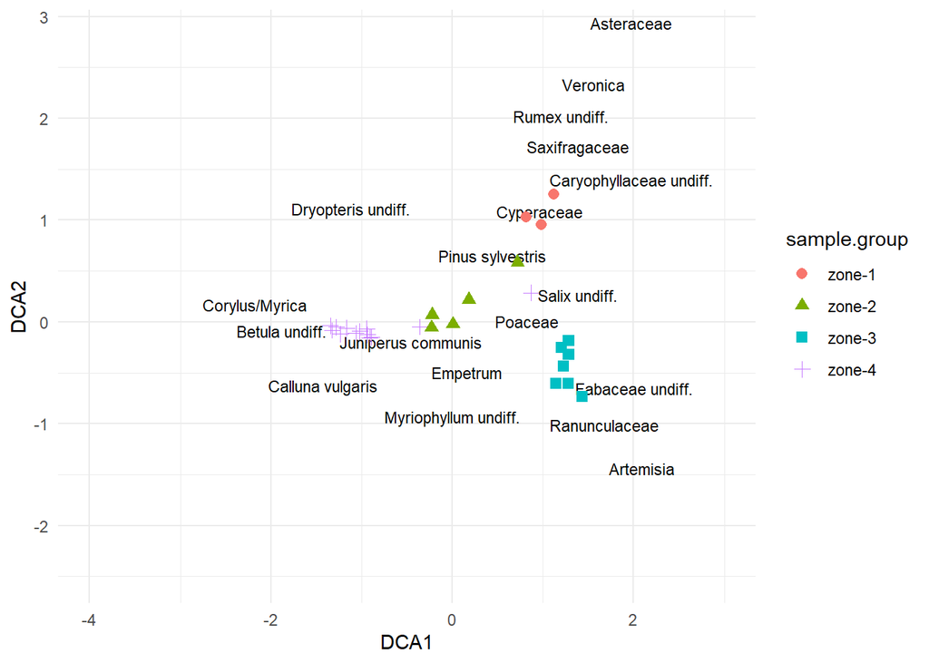

```r
ggplot(data = dca.species, aes(x=DCA1, y=DCA2, label = rownames(dca.species))) +
  geom_text_repel(direction = "both", size = 3) +
  geom_point(data = dca.samples.group, inherit.aes = FALSE, aes(x = DCA1, y = DCA2, shape = sample.group, color=sample.group), size = 2.5) +
  coord_cartesian(
    xlim = c(-4,3),
    ylim = c(-2.5,2.8),
    expand = TRUE
  )+
  theme_minimal()
```

We might try to improve this plot by adding in highest density regions (hdr). This should not usually be necessary, but can highlight where differences might occur more clearly.

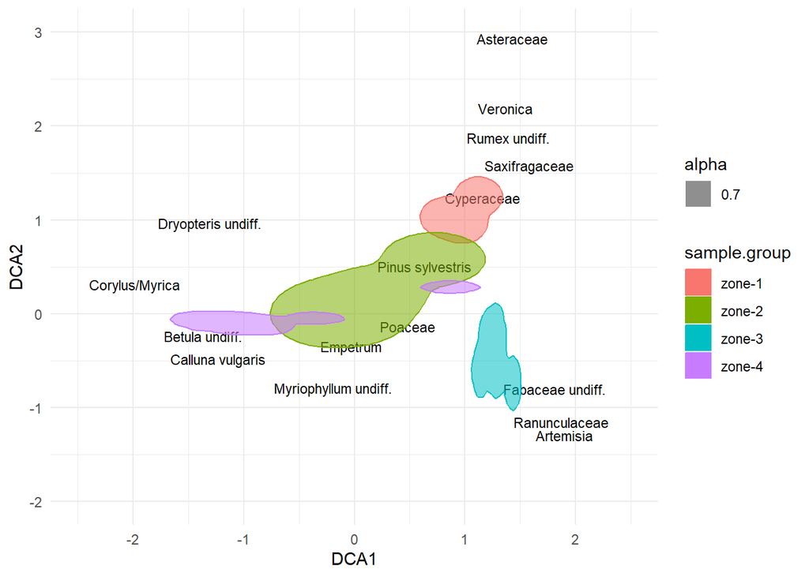

```r
ggplot(data = dca.species,
       aes(x=DCA1, y=DCA2, label = rownames(dca.species))) +
  geom_text(check_overlap = TRUE,
            size = 3) +
  geom_hdr(data = dca.samples.group, inherit.aes = FALSE,
           aes(x = DCA1, y = DCA2, color=sample.group, fill = sample.group, alpha = 0.7),
           probs = c(0.95)) +
  coord_cartesian(
    xlim = c(-2.5,2.5),
    ylim = c(-2,3),
    expand = TRUE
  )+
  theme_minimal()
```

This shows us that zone 1 and three have the most positive position and therefore most open ground taxa with zone four having the most tree and woddy shrub cover. Zone 2 is more variable.

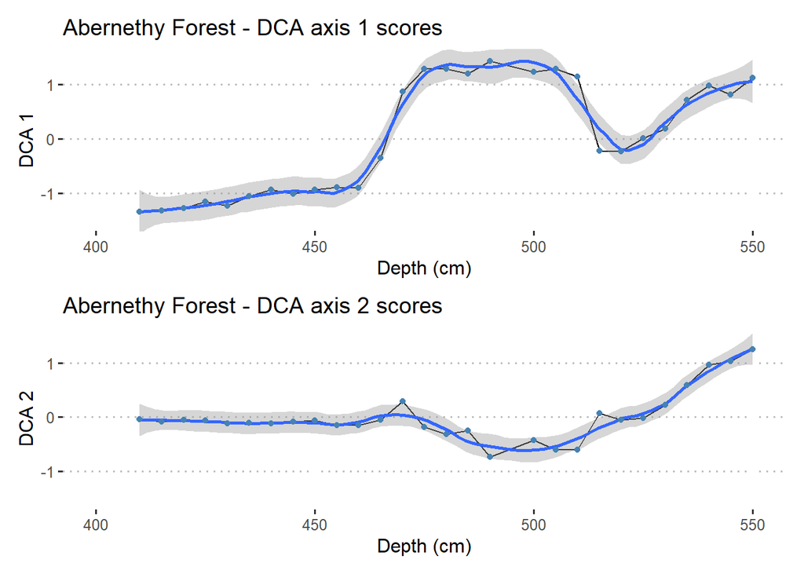

```r
p1 <- ggplot(dca.samples, aes(Depth, DCA1)) +
  geom_line() +
   geom_smooth(span = 0.3)+
  coord_cartesian(xlim = c(400,550), ylim = c(-1.55,1.5)) +
  geom_point(colour = "steelblue",)+
  labs(y = "DCA 1", x = "Depth (cm)") +
  ggtitle("Abernethy Forest - DCA axis 1 scores")+
  theme_pubclean()

p2 <- ggplot(dca.samples, aes(Depth, DCA2)) +
  geom_line() +
   geom_smooth(span = 0.3)+
coord_cartesian(xlim = c(400,550), ylim = c(-1.55,1.5)) +
  geom_point(colour = "steelblue",)+
  labs(y = "DCA 2", x = "Depth (cm)") +
  ggtitle("Abernethy Forest - DCA axis 2 scores")+
  theme_pubclean()

print(p1/p2) # we are using patchwork here to stack our charts
```

### Transformations of multivariate data for linear methods.

There is justified criticism of DCA as an approach in that it is artificially straightening the data with no strong rationale for those adjustments. However it remains useful and as this is part of data exploration it should be treated as a tool for understanding groups or variation within your data rather than something more quantified. The proposed transformations can be accessed via the `decostand()` function in the `vegan` package. This provides lots of options for transforming data in order to better reflect the true distances between specific taxa and samples. Two we will try here are `method = hellinger` and `method = rclr`. These are recommended for compositional data transformations (see package help file for vegan for citations).

Hellinger transformation is the chord transformation applied to square root transformed frequencies/abundances Legendre and Borcard (2018).

Robust clr divides the values by geometric mean of the observed features; zero values are kept as zeroes, and not taken into account. In high dimensional data, the geometric mean of rclr is a good approximation of the true geometric mean; see e.g. Martino et al. (2019) The `rclr` transformation is defined formally as follows:

*rclr = log(x_r/g(x_r > 0))*

where *x_{r}* is a single relative value, and *g(x_{r} > 0)* is geometric mean of sample-wide relative values that are positive (over 0).

We can check the impact of these transformations using procrustes rotation:

“Procrustes rotation rotates a matrix to maximum similarity with a target matrix minimizing sum of squared differences. Procrustes rotation is typically used in comparison of ordination results. It is particularly useful in comparing alternative solutions in multidimensional scaling. If `scale=FALSE`, the function only rotates matrix `Y`. If `scale=TRUE`, it scales linearly configuration `Y` for maximum similarity. Since `Y` is scaled to fit `X`, the scaling is non-symmetric. However, with `symmetric=TRUE`, the configurations are scaled to equal dispersions and a symmetric version of the Procrustes statistic is computed.” (from function help).

The first ordination has the position of the blue arrows while the second is the open black circles.

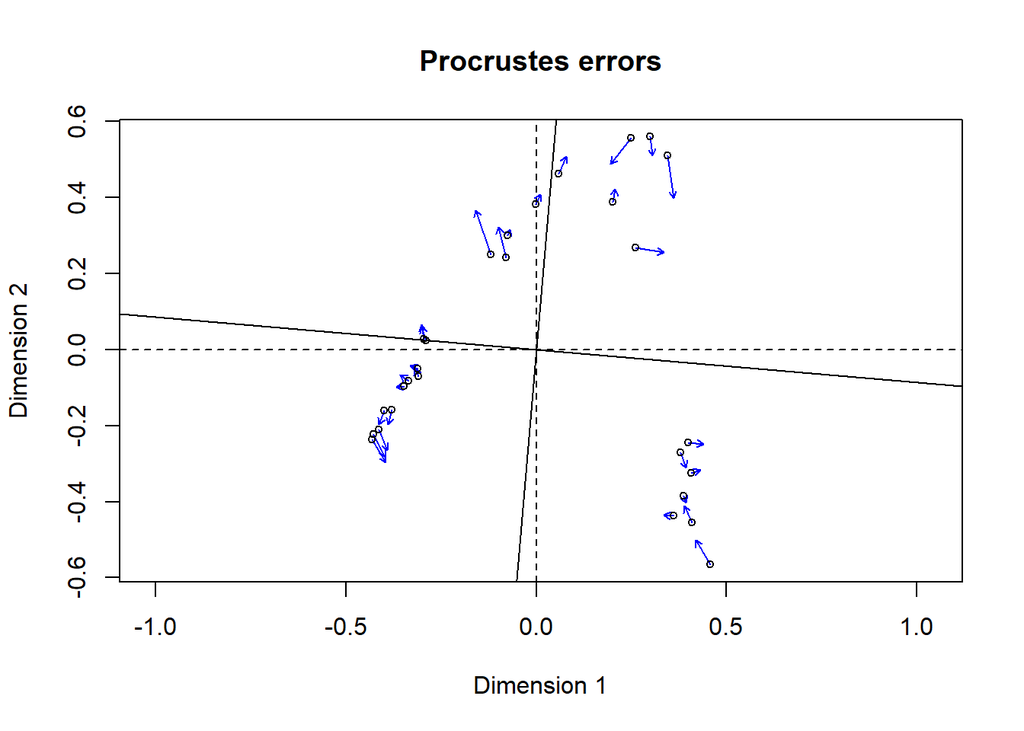

```r
spec_trans <- decostand(spec, "hellinger") # Hellinger transformation is basically the square root of relative abundance data (if rows are samples)
spec_trans2 <- decostand(spec, "rclr") # robust centred log ratio
plot(procrustes(rda(spec_trans), cca(spec)))
```

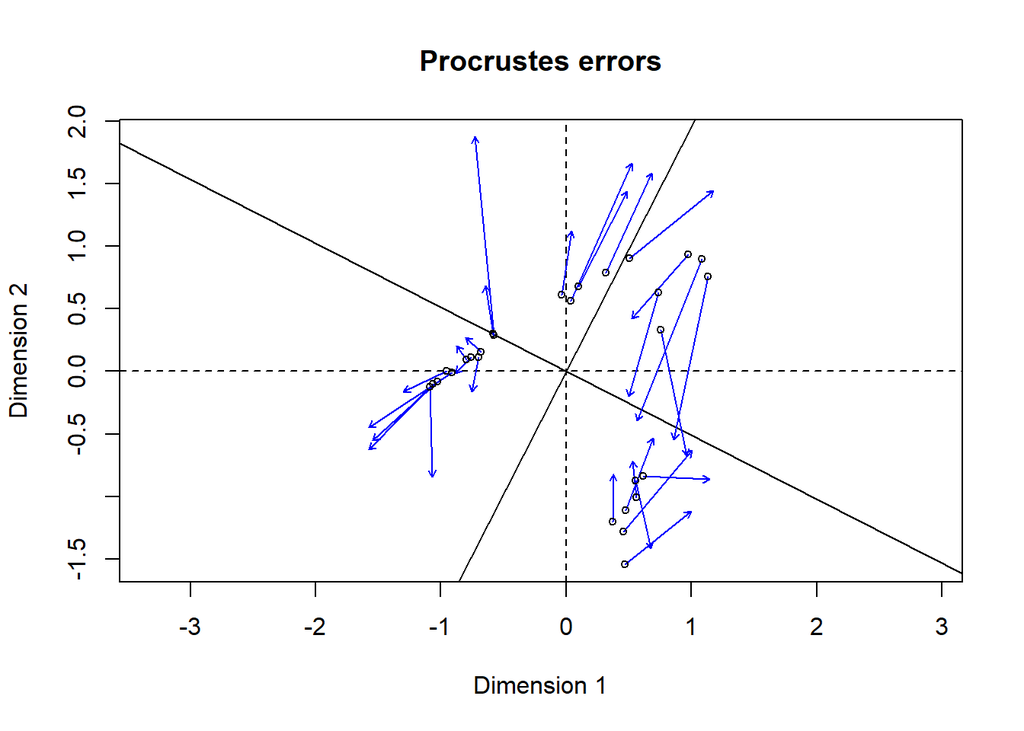

```r
plot(procrustes(rda(spec_trans2), cca(spec)))
```

There is no ‘correct’ choice, you need to think about what it means for your own data. However, here `rclr` changes the data the most. You should now be able to use linear approaches to your data (RDA and PCA). The next few lines of code will perform PCA plots on the transformed data, with Hellinger first and then rclr. Look at these and compare them to the untransformed data you produced above.

```r
pcascores_trans <- prcomp(spec_trans, scale. = TRUE, center = TRUE)
summary(pcascores_trans) ## hellinger transform applied
```

```
Importance of components:
                          PC1    PC2    PC3     PC4     PC5     PC6     PC7
Standard deviation     2.8243 1.8328 1.5972 1.07576 0.99189 0.88269 0.82066
Proportion of Variance 0.4198 0.1768 0.1343 0.06091 0.05178 0.04101 0.03545
Cumulative Proportion  0.4198 0.5966 0.7309 0.79180 0.84359 0.88459 0.92004
                           PC8     PC9    PC10    PC11    PC12    PC13    PC14
Standard deviation     0.59315 0.54011 0.50185 0.45225 0.38530 0.31772 0.28361
Proportion of Variance 0.01852 0.01535 0.01326 0.01076 0.00781 0.00531 0.00423
Cumulative Proportion  0.93856 0.95391 0.96716 0.97793 0.98574 0.99106 0.99529
                          PC15    PC16    PC17    PC18    PC19
Standard deviation     0.20562 0.14848 0.11896 0.09472 0.04531
Proportion of Variance 0.00223 0.00116 0.00074 0.00047 0.00011
Cumulative Proportion  0.99751 0.99867 0.99942 0.99989 1.00000
```

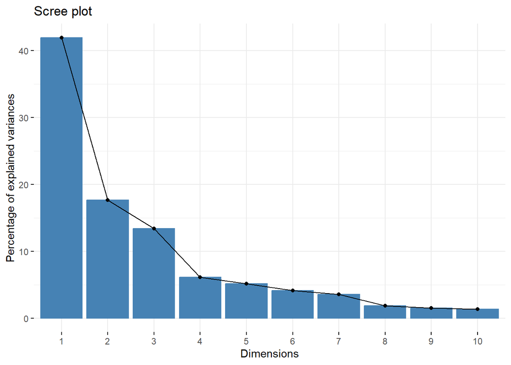

```r
fviz_eig(pcascores_trans)
```

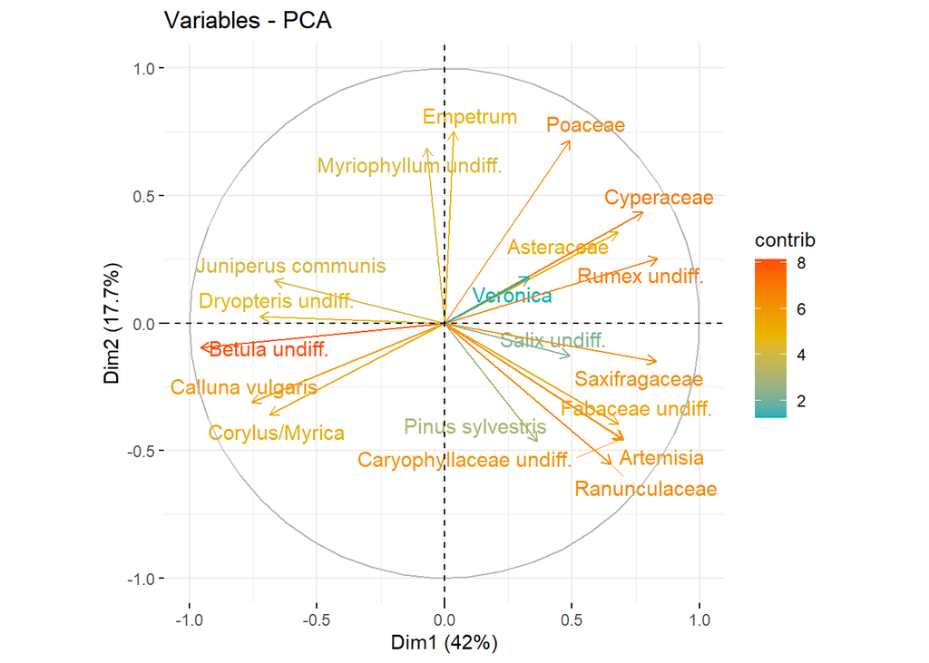

```r
fviz_pca_var(pcascores_trans, col.var = "contrib", # Color by contributions to the PC
             gradient.cols = c("#00AFBB", "#E7B800", "#FC4E07"),
             repel = TRUE)     # Avoid text overlapping
```

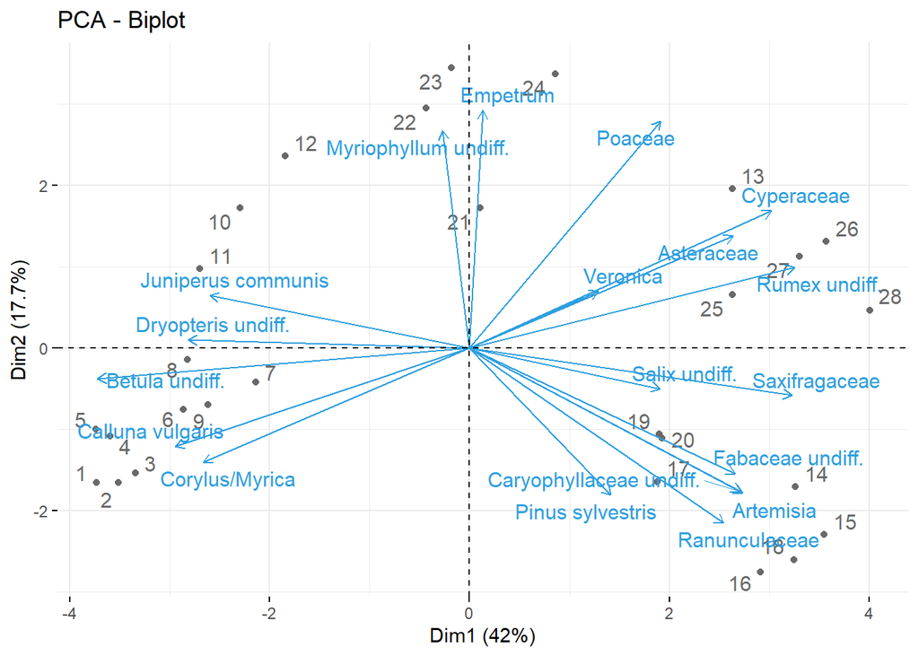

```r
fviz_pca_biplot(pcascores_trans, repel = TRUE,
                col.var = "#2E9FDF", # Variables color
                col.ind = "#696969")  # Individuals color
```

The Hellinger transform means 41.98% of all variation is captured in axis 1 with another 17.68% in axis 2. The most important variables are the same as in the untransformed data.

```r
pcascores_trans2 <- prcomp(spec_trans2, scale. = TRUE, center = TRUE)
summary(pcascores_trans2) # rclr method
```

```
Importance of components:
                          PC1    PC2    PC3     PC4     PC5     PC6     PC7
Standard deviation     2.2931 1.8239 1.4435 1.26323 1.23723 1.08943 0.94935
Proportion of Variance 0.2767 0.1751 0.1097 0.08399 0.08057 0.06247 0.04743
Cumulative Proportion  0.2767 0.4518 0.5615 0.64549 0.72605 0.78852 0.83595
                           PC8     PC9    PC10    PC11    PC12    PC13    PC14
Standard deviation     0.89270 0.81060 0.74435 0.56424 0.49107 0.47120 0.37196
Proportion of Variance 0.04194 0.03458 0.02916 0.01676 0.01269 0.01169 0.00728
Cumulative Proportion  0.87790 0.91248 0.94164 0.95840 0.97109 0.98277 0.99005
                          PC15   PC16   PC17   PC18      PC19
Standard deviation     0.30366 0.2346 0.1687 0.1151 2.539e-16
Proportion of Variance 0.00485 0.0029 0.0015 0.0007 0.000e+00
Cumulative Proportion  0.99491 0.9978 0.9993 1.0000 1.000e+00
```

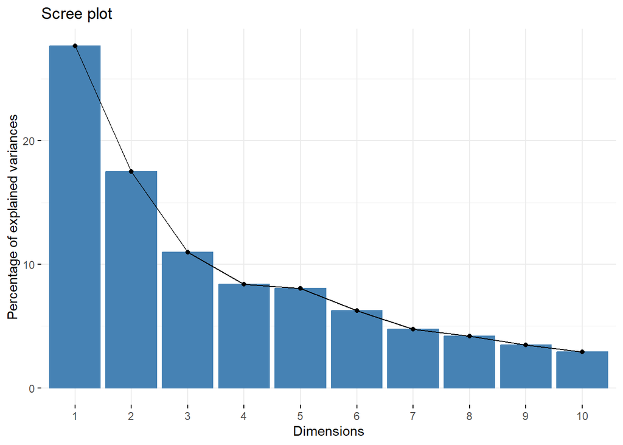

```r
fviz_eig(pcascores_trans2)
```

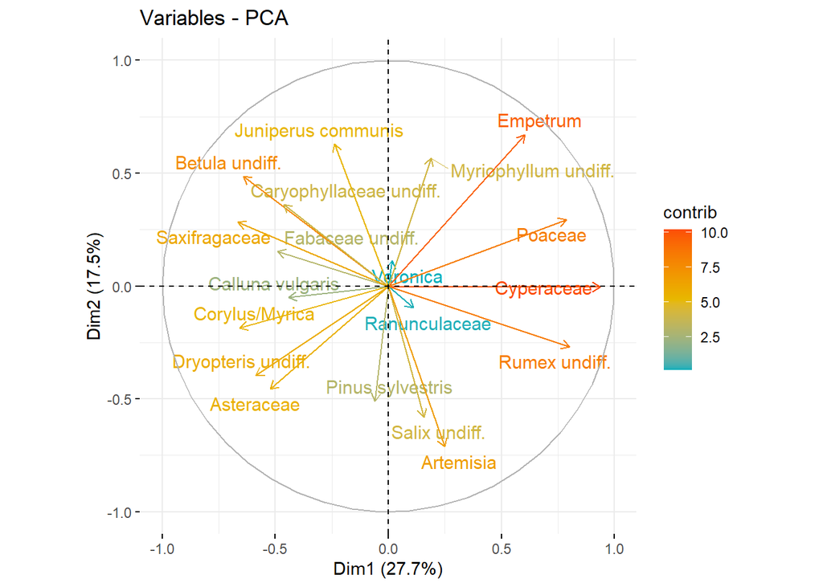

```r
fviz_pca_var(pcascores_trans2, col.var = "contrib", # Color by contributions to the PC
             gradient.cols = c("#00AFBB", "#E7B800", "#FC4E07"),
             repel = TRUE)     # Avoid text overlapping
```

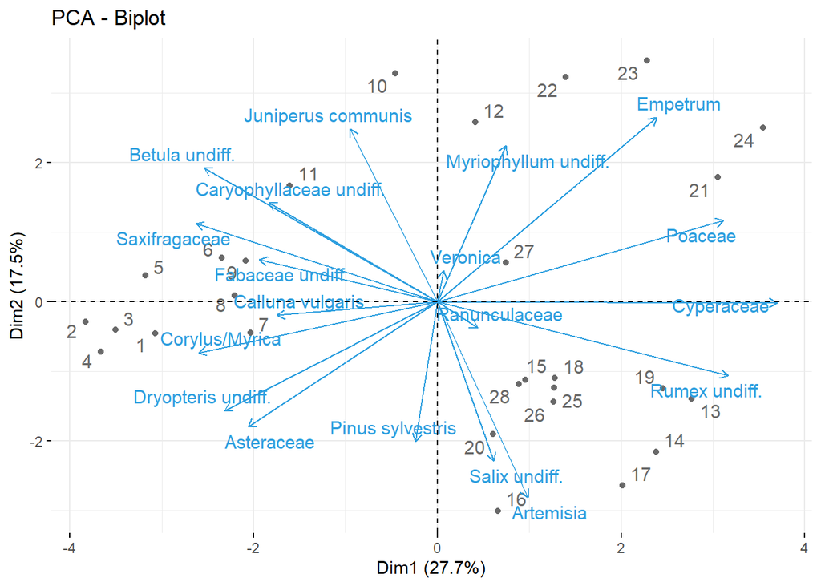

```r
fviz_pca_biplot(pcascores_trans2, repel = TRUE,
                col.var = "#2E9FDF", # Variables color
                col.ind = "#696969")  # Individuals color
```

The rclr method captures 27.67% variation in axis 1 and 17.51% in axis 2. The approach also reduces the importnance of tree cover relative to Poaceae, *Empetrum* and Cyperaceae. Applying your ecological knowledge is important here to know whether this is appropriate.

To understand the impact of each of these transformations we can plot the axis one scores for each method to see what impact it might have.

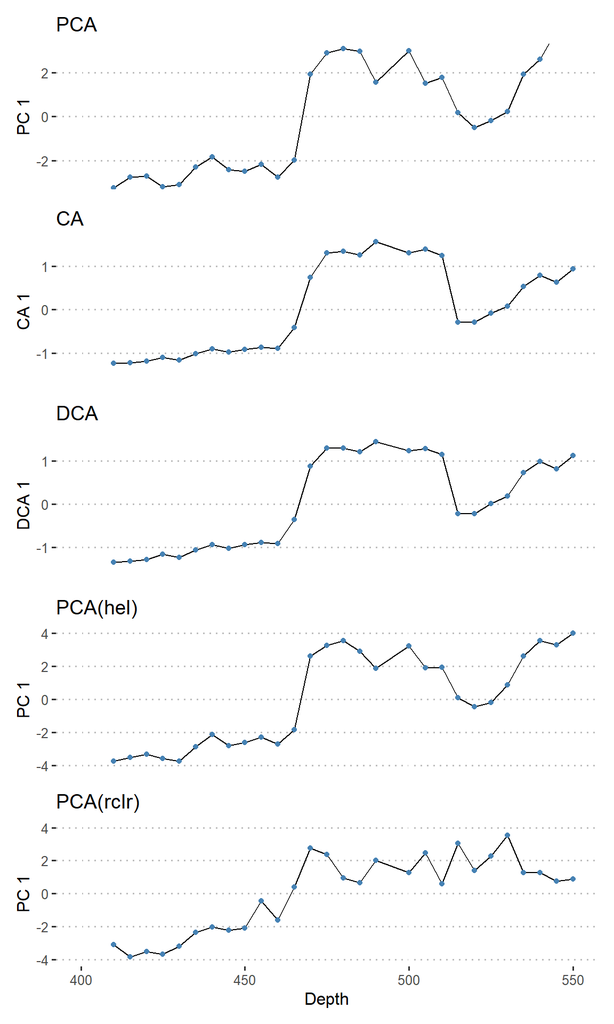

```r
pca.samples <- as.data.frame(scores(pcascores,  display = "sites", choices = 1:3))
ca.samples <- as.data.frame(scores(cca_out,  display = "sites", choices = 1:3))
pca.sampleshel <- as.data.frame(scores(pcascores_trans,  display = "sites", choices = 1:3))
pca.samplesrclr <- as.data.frame(scores(pcascores_trans2,  display = "sites", choices = 1:3))

plt_out <- as.data.frame( cbind(Depth, pca.samples$PC1,ca.samples$CA1, dca.samples$DCA1, pca.sampleshel$PC1, pca.samplesrclr$PC1  ))

g1 <- ggplot(plt_out, aes(Depth, V2)) +
  geom_line() +
   #geom_smooth(span = 0.3)+
  coord_cartesian(xlim = c(400,550), ylim = c(-3,3)) +
  geom_point(colour = "steelblue",)+
  labs(y = "PC 1") +
  ggtitle("PCA")+
  theme_pubclean() +
  theme(axis.title.x=element_blank(),
        axis.text.x=element_blank(),
        axis.ticks.x=element_blank())
g2 <- ggplot(plt_out, aes(Depth, V3)) +
  geom_line() +
   #geom_smooth(span = 0.3)+
  coord_cartesian(xlim = c(400,550), ylim = c(-1.55,1.5)) +
  geom_point(colour = "steelblue",)+
  labs(y = "CA 1") +
  ggtitle("CA")+
  theme_pubclean() +
  theme(axis.title.x=element_blank(),
        axis.text.x=element_blank(),
        axis.ticks.x=element_blank())
g3 <- ggplot(plt_out, aes(Depth, V4)) +
  geom_line() +
   #geom_smooth(span = 0.3)+
  coord_cartesian(xlim = c(400,550), ylim = c(-1.55,1.5)) +
  geom_point(colour = "steelblue",)+
  labs(y = "DCA 1") +
  ggtitle("DCA")+
  theme_pubclean() +
  theme(axis.title.x=element_blank(),
        axis.text.x=element_blank(),
        axis.ticks.x=element_blank())
g4 <- ggplot(plt_out, aes(Depth, V5)) +
  geom_line() +
   #geom_smooth(span = 0.3)+
  coord_cartesian(xlim = c(400,550), ylim = c(-4,4)) +
  geom_point(colour = "steelblue",)+
  labs(y = "PC 1") +
  ggtitle("PCA(hel)")+
  theme_pubclean() +
  theme(axis.title.x=element_blank(),
        axis.text.x=element_blank(),
        axis.ticks.x=element_blank())
g5 <- ggplot(plt_out, aes(Depth, V6)) +
  geom_line() +
   #geom_smooth(span = 0.3)+
  coord_cartesian(xlim = c(400,550), ylim = c(-4,4)) +
  geom_point(colour = "steelblue",)+
  labs(y = "PC 1") +
  ggtitle("PCA(rclr)")+
  theme_pubclean()

g1/g2/g3/g4/g5
```

The PCA(rclr) produces a result which looks unlike any of the other approaches and you will need to think about whether this is helpful. Conversly the Hellinger transformed PCA captures the most variation of any approach in axis one (nearly 42%), it seems an interesting combination of both PCA and DCA results and this might add credibility.

## Direct Ordination

We will use a modern dataset for this direct ordination where we are trying to determine which environmental variables influence species abundances. We will use a Norwegian chironomidae dataset collected from lakes from Svalbard down to Southern Norway. The samples collected were the larval stage from within the lake. At each location modern environmental data were collected from those locations e.g. water quality, temperature etc… The objective is to try and to determine how species assemblages change with differing environmental conditions. For this we need two tidy data sheets. One ordered by site containing the species data and a second ordered by site including the environmental data. This work was originally published by Brooks and Birks (2000). Ideally, the last stage would be to apply these trends to a palaeodataset, but this requires additional stages and checks on the data. We can perform this another time if you wish to know more about this.

```r
N_Chiros <- read_csv("NORQRAPC.csv", show_col_types = FALSE) # species data
N_chiros_t <-N_Chiros [-c(13, 111, 134, 139),] # outlier sites removed
NORENV <- read_csv("NORENV.csv", show_col_types = FALSE) # environmental data
NORENV_t <-NORENV [-c(13, 111, 134, 139),] # outlier sites removed
N_chiros_t <- N_chiros_t[-c(1)] # remove site code
N_chiros_trans <- sqrt(N_chiros_t/100) # standardise the counts

NORENV_t <- NORENV_t [-c(1)] # lose site code

gt(head(N_Chiros, 15))
```

| Site | Abiskomy | Ablabesm | Acamptoc | Allopsec | Brillia | Bryophae | Chaetocl | Chir ant | Chir lar | Chir plu | Clad man | Clad spu | Cladopel | Cory amb | Cory cor | Cory edw | Coryno A | Cory lob | Cory oli | Cory arc | Cric tri | Orth tri | Cric ind | Crico P | Cric syl | Cric cyl | Orth oli | Crico C | Cric lar | … |
| --- | --- | --- | --- | --- | --- | --- | --- | --- | --- | --- | --- | --- | --- | --- | --- | --- | --- | --- | --- | --- | --- | --- | --- | --- | --- | --- | --- | --- | --- | --- |
| 1 | 0 | 0 | 0 | 0 | 0 | 0 | 0 | 0 | 0 | 0 | 0 | 0 | 0 | 0 | 0 | 0 | 0 | 0 | 0.0000000 | 0 | 0 | 0.0000000 | 0 | 0 | 0 | 0 | 0 | 0 | 0 | … |
| 2 | 0 | 0 | 0 | 0 | 0 | 0 | 0 | 0 | 0 | 0 | 0 | 0 | 0 | 0 | 0 | 0 | 0 | 0 | 0.0000000 | 0 | 0 | 1.4084507 | 0 | 0 | 0 | 0 | 0 | 0 | 0 | … |
| 3 | 0 | 0 | 0 | 0 | 0 | 0 | 0 | 0 | 0 | 0 | 0 | 0 | 0 | 0 | 0 | 0 | 0 | 0 | 1.8018018 | 0 | 0 | 11.7117119 | 0 | 0 | 0 | 0 | 0 | 0 | 0 | … |
| 4 | 0 | 0 | 0 | 0 | 0 | 0 | 0 | 0 | 0 | 0 | 0 | 0 | 0 | 0 | 0 | 0 | 0 | 0 | 0.0000000 | 0 | 0 | 0.0000000 | 0 | 0 | 0 | 0 | 0 | 0 | 0 | … |
| 5 | 0 | 0 | 0 | 0 | 0 | 0 | 0 | 0 | 0 | 0 | 0 | 0 | 0 | 0 | 0 | 0 | 0 | 0 | 3.7500000 | 0 | 0 | 3.7500000 | 0 | 0 | 0 | 0 | 0 | 0 | 0 | … |
| 6 | 0 | 0 | 0 | 0 | 0 | 0 | 0 | 0 | 0 | 0 | 0 | 0 | 0 | 0 | 0 | 0 | 0 | 0 | 2.1897810 | 0 | 0 | 5.8394160 | 0 | 0 | 0 | 0 | 0 | 0 | 0 | … |
| 7 | 0 | 0 | 0 | 0 | 0 | 0 | 0 | 0 | 0 | 0 | 0 | 0 | 0 | 0 | 0 | 0 | 0 | 0 | 0.0000000 | 0 | 0 | 2.8673835 | 0 | 0 | 0 | 0 | 0 | 0 | 0 | … |
| 8 | 0 | 0 | 0 | 0 | 0 | 0 | 0 | 0 | 0 | 0 | 0 | 0 | 0 | 0 | 0 | 0 | 0 | 0 | 0.0000000 | 0 | 0 | 1.0869565 | 0 | 0 | 0 | 0 | 0 | 0 | 0 | … |
| 9 | 0 | 0 | 0 | 0 | 0 | 0 | 0 | 0 | 0 | 0 | 0 | 0 | 0 | 0 | 0 | 0 | 0 | 0 | 0.0000000 | 0 | 0 | 0.0000000 | 0 | 0 | 0 | 0 | 0 | 0 | 0 | … |
| 10 | 0 | 0 | 0 | 0 | 0 | 0 | 0 | 0 | 0 | 0 | 0 | 0 | 0 | 0 | 0 | 0 | 0 | 0 | 0.0000000 | 0 | 0 | 2.8571429 | 0 | 0 | 0 | 0 | 0 | 0 | 0 | … |
| 11 | 0 | 0 | 0 | 0 | 0 | 0 | 0 | 0 | 0 | 0 | 0 | 0 | 0 | 0 | 0 | 0 | 0 | 0 | 0.0000000 | 0 | 0 | 1.4705882 | 0 | 0 | 0 | 0 | 0 | 0 | 0 | … |
| 12 | 0 | 0 | 0 | 0 | 0 | 0 | 0 | 0 | 0 | 0 | 0 | 0 | 0 | 0 | 0 | 0 | 0 | 0 | 0.0000000 | 0 | 0 | 9.5000000 | 0 | 0 | 0 | 0 | 0 | 0 | 0 | … |
| 13 | 0 | 0 | 0 | 0 | 0 | 0 | 0 | 0 | 0 | 0 | 0 | 0 | 0 | 0 | 0 | 0 | 0 | 0 | 0.5181347 | 0 | 0 | 0.0000000 | 0 | 0 | 0 | 0 | 0 | 0 | 0 | … |
| 14 | 0 | 0 | 0 | 0 | 0 | 0 | 0 | 0 | 0 | 0 | 0 | 0 | 0 | 0 | 0 | 0 | 0 | 0 | 0.0000000 | 0 | 0 | 0.0000000 | 0 | 0 | 0 | 0 | 0 | 0 | 0 | … |
| 15 | 0 | 0 | 0 | 0 | 0 | 0 | 0 | 0 | 0 | 0 | 0 | 0 | 0 | 0 | 0 | 0 | 0 | 0 | 2.9411764 | 0 | 0 | 0.4901961 | 0 | 0 | 0 | 0 | 0 | 0 | 0 | … |

```r
gt(head(NORENV, 15))
```

| Sample | Depth | July t | Water t | pH | Alk | Ca | Cl | Cond | K | Mg | NO3 | Na | SO4 | TOC |
| --- | --- | --- | --- | --- | --- | --- | --- | --- | --- | --- | --- | --- | --- | --- |
| 1 | 0.9 | 6.0 | 6.6 | 8.2 | 992 | 853.3 | 342.4 | 169 | 12.8 | 411.3 | 5.2 | 278.4 | 41.5 | 0.1 |
| 2 | 2.2 | 6.0 | 6.0 | 8.4 | 832 | 863.3 | 227.1 | 189 | 15.4 | 466.4 | 0.6 | 356.7 | 41.5 | 0.1 |
| 3 | 26.0 | 4.7 | 6.3 | 8.0 | 608 | 1042.9 | 76.7 | 153 | 20.5 | 439.3 | 0.0 | 108.7 | 50.8 | 0.1 |
| 4 | 1.3 | 4.5 | 6.5 | 6.8 | 136 | 144.7 | 87.5 | 44 | 48.6 | 83.9 | 0.5 | 113.1 | 19.0 | 0.1 |
| 5 | 1.4 | 4.5 | 5.2 | 7.1 | 306 | 239.5 | 151.0 | 28 | 35.8 | 171.1 | 0.0 | 152.2 | 45.5 | 0.1 |
| 6 | 1.5 | 4.5 | 8.0 | 6.6 | 120 | 49.9 | 69.3 | 133 | 7.7 | 29.6 | 1.5 | 43.5 | 25.4 | 0.1 |
| 7 | 5.1 | 4.5 | 7.6 | 6.5 | 88 | 44.9 | 63.6 | 33 | 17.9 | 38.7 | 0.0 | 60.9 | 19.9 | 0.2 |
| 8 | 11.5 | 4.5 | 8.3 | 6.6 | 104 | 49.9 | 66.3 | 26 | 10.2 | 38.7 | 0.6 | 60.9 | 22.3 | 0.1 |
| 9 | 6.8 | 3.5 | 7.5 | 5.6 | 72 | 20.0 | 90.2 | 22 | 15.4 | 36.2 | 0.6 | 121.8 | 16.7 | 0.1 |
| 10 | 6.7 | 3.5 | 4.7 | 6.1 | 64 | 24.9 | 241.0 | 69 | 12.8 | 83.9 | 1.4 | 300.1 | 26.3 | 0.1 |
| 11 | 12.5 | 3.5 | 2.7 | 6.3 | 80 | 49.9 | 35.9 | 76 | 7.7 | 22.2 | 0.5 | 56.6 | 7.3 | 0.1 |
| 12 | 5.1 | 3.5 | 3.6 | 5.8 | 52 | 24.9 | 142.3 | 34 | 7.7 | 32.9 | 0.5 | 104.4 | 27.1 | 0.1 |
| 13 | 2.1 | 3.5 | 4.0 | 6.1 | 36 | 20.0 | 49.9 | 12 | 7.7 | 23.9 | 0.0 | 69.6 | 11.5 | 0.1 |
| 14 | 2.0 | 3.5 | 3.9 | 7.6 | 40 | 434.1 | 65.0 | 129 | 12.8 | 159.6 | 1.0 | 234.9 | 15.0 | 0.1 |
| 15 | 6.7 | 4.7 | 8.5 | 8.1 | 600 | 3004.0 | 66.5 | 367 | 74.2 | 930.4 | 4.5 | 178.3 | 1225.7 | 0.1 |

```r
chiro_ord <- decorana(N_chiros_trans, iweigh = 1) ### check axis length to see which might be appropriate ordination technique
chiro_ord
```

```
Call:
decorana(veg = N_chiros_trans, iweigh = 1)

Detrended correspondence analysis with 26 segments.
Rescaling of axes with 4 iterations.
Downweighting of rare species from fraction 1/5.
Total inertia (scaled Chi-square): NaN

                       DCA1   DCA2   DCA3    DCA4
Eigenvalues          0.4424 0.2280 0.1506 0.11077
Additive Eigenvalues 0.0000 0.0000 0.0000 0.00000
Decorana values      0.5798 0.2116 0.1226 0.08125
Axis lengths         5.8348 3.6713 2.1508 2.43788
```

The length of gradient is 5.84 which is too long for linear techniques. Here we can apply cca or again transform our data. First we run all of our species against all of our collected environmental variables.

```r
CCA <- cca(N_chiros_trans, NORENV_t) # this includes all environmental variables
CCA
```

```
Call: cca(X = N_chiros_trans, Y = NORENV_t)

-- Model Summary --

              Inertia Proportion Rank
Total          5.1610     1.0000
Constrained    1.1791     0.2285   14
Unconstrained  3.9819     0.7715  135

Inertia is scaled Chi-square

-- Note --

2 species (variables) deleted due to missingness.

-- Eigenvalues --

Eigenvalues for constrained axes:
  CCA1   CCA2   CCA3   CCA4   CCA5   CCA6   CCA7   CCA8   CCA9  CCA10  CCA11
0.4715 0.1898 0.1340 0.0776 0.0546 0.0465 0.0380 0.0336 0.0311 0.0264 0.0241
 CCA12  CCA13  CCA14
0.0225 0.0198 0.0095

Eigenvalues for unconstrained axes:
   CA1    CA2    CA3    CA4    CA5    CA6    CA7    CA8
0.3972 0.2492 0.1995 0.1621 0.1513 0.1423 0.1342 0.1126
(Showing 8 of 135 unconstrained eigenvalues)
```

```r
varExpl(CCA, pcent = TRUE) # extract the percentage explained by axis 1.
```

```
    CCA1
9.135713
```

Our environmental variables constrain 1.18 of a total inertia of 5.16 in the taxa (about 22.8% of the total variation has been captured by our variables, but it means a lot more has not been captured by these variables. We can plot the results using ggvegan to produce a nice plot, and other ggplot extensions exist for the output of vegan analyses. The plot below shows the sites, species and environmental variables. The longest most horizontal arrows relating to our line of maximum variation i.e. axis 1 are water temperature and July air temperature. The first relates to ambient conditions for the larvae while the second relates to air temperatures during the reproductive cycle.

```r
install.packages("remotes")
remotes::install_github("gavinsimpson/ggvegan")
```

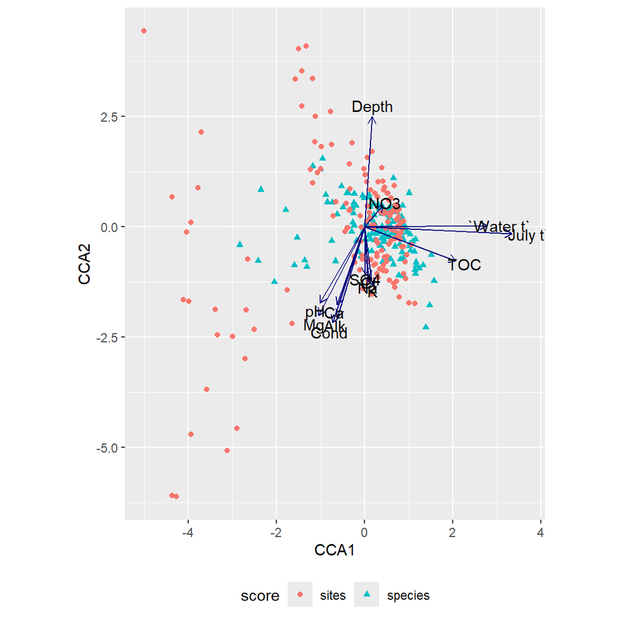

```r
library(ggvegan)
autoplot(CCA,
         legend.position = "bottom")
```

Laboratory experiments showed that one of the most important things determining chironomid assemblages was the temperature of the air during the period of reproduction. We can test the cca just against July air temperature by specifying our preferred variable.

```r
CCA2 <- cca(N_chiros_trans~NORENV_t$`July t`)
CCA2
```

```
Call: cca(formula = N_chiros_trans ~ NORENV_t$`July t`)

-- Model Summary --

              Inertia Proportion Rank
Total         5.16095    1.00000
Constrained   0.42571    0.08249    1
Unconstrained 4.73524    0.91751  135

Inertia is scaled Chi-square

-- Note --

2 species (variables) deleted due to missingness.

-- Eigenvalues --

Eigenvalues for constrained axes:
  CCA1
0.4257

Eigenvalues for unconstrained axes:
   CA1    CA2    CA3    CA4    CA5    CA6    CA7    CA8
0.4362 0.3852 0.2860 0.1993 0.1829 0.1650 0.1503 0.1420
(Showing 8 of 135 unconstrained eigenvalues)
```

```r
varExpl(CCA2, pcent = TRUE)
```

```
    CCA1
8.248607
```

In this case our single constrained variable explains 8.25 % of the total variation in the species dataset. Again we can plot this against just July temperatures and then see how the ordinations change using the procrustes approach.

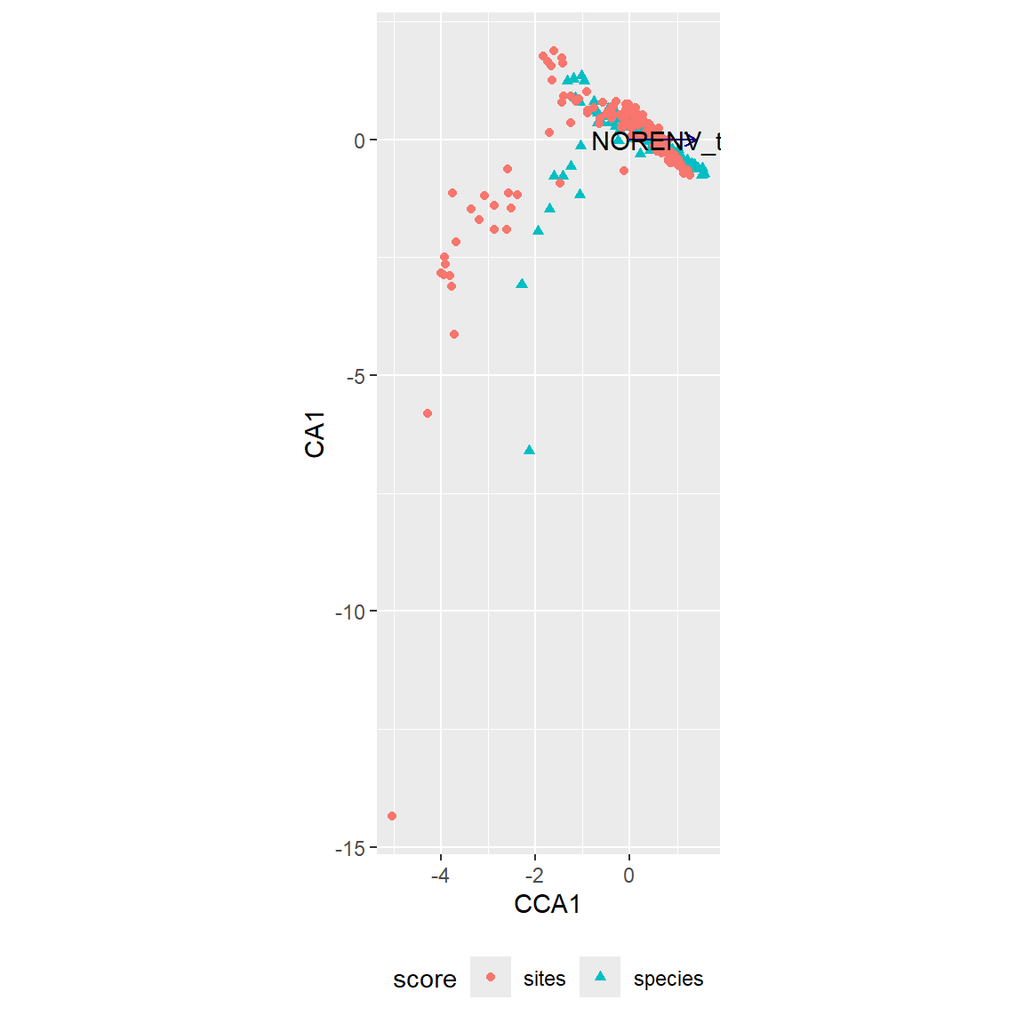

```r
autoplot(CCA2,
         legend.position = "bottom")
```

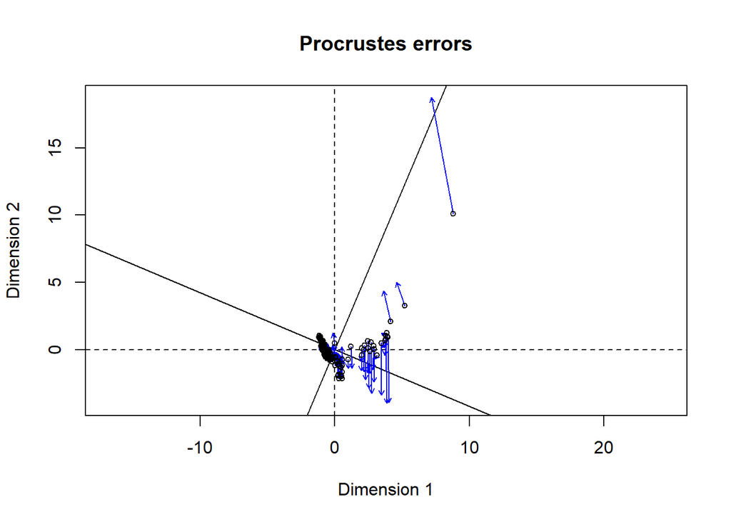

```r
plot(procrustes(cca(N_chiros_trans), CCA2))
```

We can see one single lake is strongly impacted by this. This lake is a Svalbard example and may be influenced by other factors than temperature (nutrient availability).

Ideally we should be attempting to identify meaningful /significant environmental variables rather than working on each in turn. We will choose a model by applying a stepwise algorithm assessed by AIC. It adds significant environmental variables until eventually generating the best model, which in this case is `N_chiros_trans ~ July t + Depth + Cond + TOC + Alk`. So July temperature, water depth, total organic carbon, and alkalinity are significant to our species assemblages. With these combined axis 1 of the cca constrains 8.5 % of the total variability. However, as July temperatures were able to capture 8.24% on its own it would suggest the impacts of the other factors are very slight.

```r
mod0 <- cca(N_chiros_trans ~ 1, NORENV_t) # unconstrained
mod0
```

```
Call: cca(formula = N_chiros_trans ~ 1, data = NORENV_t)

-- Model Summary --

              Inertia Rank
Total           5.161
Unconstrained   5.161  135

Inertia is scaled Chi-square

-- Note --

2 species (variables) deleted due to missingness.

-- Eigenvalues --

Eigenvalues for unconstrained axes:
   CA1    CA2    CA3    CA4    CA5    CA6    CA7    CA8
0.6102 0.3942 0.3540 0.2288 0.1880 0.1827 0.1639 0.1446
(Showing 8 of 135 unconstrained eigenvalues)
```

```r
mod1 <- cca(N_chiros_trans ~ ., NORENV_t) # constrained with environmental variables.
mod1
```

```
Call: cca(formula = N_chiros_trans ~ Depth + `July t` + `Water t` + pH +
Alk + Ca + Cl + Cond + K + Mg + NO3 + Na + SO4 + TOC, data = NORENV_t)

-- Model Summary --

              Inertia Proportion Rank
Total          5.1610     1.0000
Constrained    1.1791     0.2285   14
Unconstrained  3.9819     0.7715  135

Inertia is scaled Chi-square

-- Note --

2 species (variables) deleted due to missingness.

-- Eigenvalues --

Eigenvalues for constrained axes:
  CCA1   CCA2   CCA3   CCA4   CCA5   CCA6   CCA7   CCA8   CCA9  CCA10  CCA11
0.4715 0.1898 0.1340 0.0776 0.0546 0.0465 0.0380 0.0336 0.0311 0.0264 0.0241
 CCA12  CCA13  CCA14
0.0225 0.0198 0.0095

Eigenvalues for unconstrained axes:
   CA1    CA2    CA3    CA4    CA5    CA6    CA7    CA8
0.3972 0.2492 0.1995 0.1621 0.1513 0.1423 0.1342 0.1126
(Showing 8 of 135 unconstrained eigenvalues)
```

```r
mod <- step(mod0, scope = formula(mod1), test = "perm") ## from all variables to entirely unconstrained.
```

```
Start:  AIC=466.42
N_chiros_trans ~ 1

            Df    AIC       F Pr(>F)
+ `July t`   1 455.25 13.5752  0.005 **
+ `Water t`  1 458.47 10.1452  0.005 **
+ TOC        1 461.93  6.5501  0.005 **
+ Depth      1 464.55  3.8715  0.005 **
+ Mg         1 464.75  3.6628  0.005 **
+ Cond       1 464.98  3.4405  0.005 **
+ pH         1 465.29  3.1183  0.005 **
+ Alk        1 465.39  3.0196  0.005 **
+ Ca         1 465.97  2.4361  0.005 **
+ Na         1 466.37  2.0345  0.020 *
<none>         466.42
+ Cl         1 466.49  1.9203  0.025 *
+ NO3        1 466.81  1.6034  0.060 .
+ K          1 466.82  1.5881  0.020 *
+ SO4        1 467.18  1.2317  0.185
---
Signif. codes:  0 '***' 0.001 '**' 0.01 '*' 0.05 '.' 0.1 ' ' 1

Step:  AIC=455.25
N_chiros_trans ~ `July t`

            Df    AIC       F Pr(>F)
+ Depth      1 452.87  4.3527  0.005 **
+ Cond       1 453.78  3.4419  0.005 **
+ Mg         1 454.04  3.1802  0.005 **
+ Alk        1 454.35  2.8735  0.005 **
+ TOC        1 454.82  2.3970  0.005 **
+ pH         1 454.87  2.3485  0.005 **
+ Ca         1 454.96  2.2595  0.005 **
+ Na         1 455.00  2.2193  0.020 *
+ `Water t`  1 455.08  2.1451  0.005 **
+ Cl         1 455.13  2.0924  0.030 *
<none>         455.25
+ K          1 455.55  1.6775  0.015 *
+ NO3        1 455.69  1.5355  0.100 .
+ SO4        1 455.90  1.3324  0.140
```

[output cut: 76 more lines]

```
+ `Water t`  1 451.25 1.6623  0.005 **
+ SO4        1 451.33 1.5823  0.105
+ Na         1 451.47 1.4472  0.070 .
+ NO3        1 451.54 1.3810  0.100 .
- TOC        1 451.58 2.5221  0.005 **
+ Mg         1 451.61 1.3087  0.100 .
+ Cl         1 451.69 1.2329  0.200
+ K          1 451.75 1.1790  0.110
+ pH         1 451.88 1.0557  0.230
+ Ca         1 451.96 0.9789  0.345
- Cond       1 452.17 3.0979  0.005 **
- Depth      1 452.82 3.7346  0.005 **
- `July t`   1 458.77 9.7183  0.005 **
---
Signif. codes:  0 '***' 0.001 '**' 0.01 '*' 0.05 '.' 0.1 ' ' 1
```

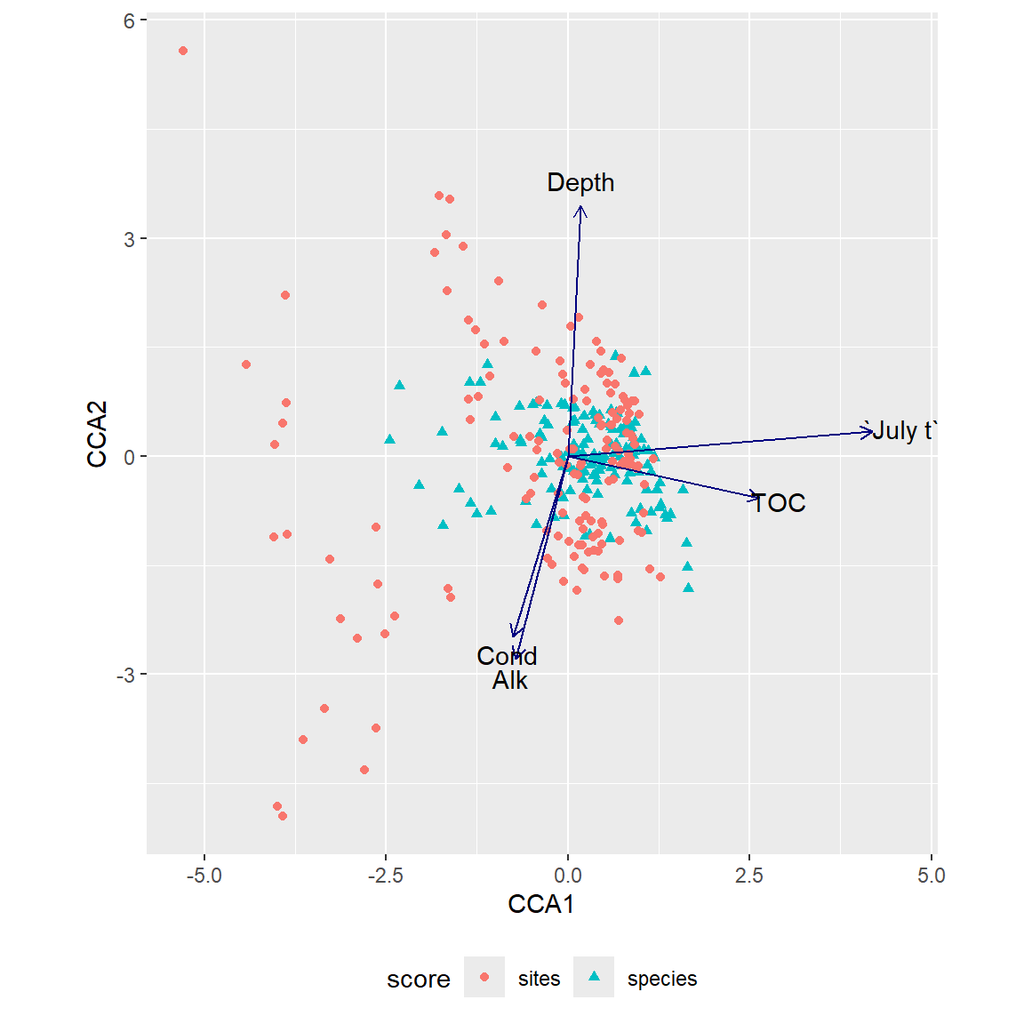

```r
autoplot(mod,
         legend.position = "bottom")
```

```r
varExpl(mod, pcent = TRUE)
```

```
    CCA1
8.506571
```

Overall, our data suggest that chironomidae species assemblages are affected by July air temperatures and changes in these are likely to alter our ecosystems in the future.

## References

Birks, Hilary H. 1970. “Studies in the Vegetational History of Scotland: I. A Pollen Diagram from Abernethy Forest, Inverness-Shire.” *The Journal of Ecology* 58 (3): 827. https://doi.org/10.2307/2258536.

BIRKS, HILARY H., and ROLF W. MATHEWES. 1978. “Studies IN THE VEGETATIONAL HISTORY OF SCOTLAND. V. LATE DEVENSIAN AND EARLY FLANDRIAN POLLEN AND MACROFOSSIL STRATIGRAPHY AT ABERNETHY FOREST, INVERNESS-SHIRE.” *New Phytologist* 80 (2): 455–84. https://doi.org/10.1111/j.1469-8137.1978.tb01579.x.

Brooks, Stephen J., and H. J. B. Birks. 2000. “Chironomid-Inferred Late-Glacial Air Temperatures at Whitrig Bog, Southeast Scotland.” *Journal of Quaternary Science* 15 (8): 759–64. https://doi.org/10.1002/1099-1417(200012)15:8<759::aid-jqs590>3.0.co;2-v.

Legendre, Pierre, and Daniel Borcard. 2018. “Box-Cox-Chord Transformations for Community Composition Data Prior to Beta Diversity Analysis.” *Ecography* 41 (11): 1820–24. https://doi.org/10.1111/ecog.03498.

Matthews, I. P., Hilary H. Birks, A. J. Bourne, S. J. Brooks, J. J. Lowe, A. MacLeod, and S. D. F. Pyne-O’Donnell. 2011. “New Age Estimates and Climatostratigraphic Correlations for the Borrobol and Penifiler Tephras: Evidence from Abernethy Forest, Scotland.” *Journal of Quaternary Science* 26 (3): 247–52. https://doi.org/10.1002/jqs.1498.